# Predict survival of patients with heart failure

Bilski Marcel, Czupryński Michał, Durawa Jakub, Fierek Patryk

2025-01-28

# 1 Wstęp

**Biblioteki wykorzystane do analizy**

Do realizacji analizy wykorzystano następujące biblioteki w R:

- **rpart**
- **rpart.plot**
- **tidyverse**
- **lubridate**
- **caret**
- **pROC**
- **uaparserjs**
- **rcompanion**
- **boot**
- **earth**
- **ggplot2**
- **survival**
- **survMisc**
- **survminer**
- **corrplot**
- **dplyr**
- **knitr**
- **kableExtra**
- **gtools**
- **tensr**
- **CoxR2**
- **gtools**
- **MASS**
- **readxl**
- **mfp**
- **splines**
- **riskRegression**
- **pec**
- **survival**

## 1.1 Celem analizy jest:

- **Identyfikacja czynników istotnie wpływających na przeżycie pacjentów.**
- **Ocena ryzyka związanego z wybranymi zmiennymi za pomocą modelu Coxa.**
- **Analiza różnic w funkcjach przeżycia między grupami pacjentów wydzielonymi na podstawie wybranych zmiennych.**

# 2 Podsumowanie danych

```
##      age               anaemia       creatinine_phosphokinase    diabetes
##  Length:299         Min.   :0.0000   Min.   :  23.0           Min.   :0.0000
##  Class :character   1st Qu.:0.0000   1st Qu.: 116.5           1st Qu.:0.0000
##  Mode  :character   Median :0.0000   Median : 250.0           Median :0.0000
##                     Mean   :0.4314   Mean   : 581.8           Mean   :0.4181
##                     3rd Qu.:1.0000   3rd Qu.: 582.0           3rd Qu.:1.0000
##                     Max.   :1.0000   Max.   :7861.0           Max.   :1.0000
##  ejection_fraction high_blood_pressure  platelets         serum_creatinine
##  Min.   :14.00     Min.   :0.0000      Length:299         Length:299
##  1st Qu.:30.00     1st Qu.:0.0000      Class :character   Class :character
##  Median :38.00     Median :0.0000      Mode  :character   Mode  :character
##  Mean   :38.08     Mean   :0.3512
##  3rd Qu.:45.00     3rd Qu.:1.0000
##  Max.   :80.00     Max.   :1.0000
##   serum_sodium        sex            smoking            time
##  Min.   :113.0   Min.   :0.0000   Min.   :0.0000   Min.   :  4.0
##  1st Qu.:134.0   1st Qu.:0.0000   1st Qu.:0.0000   1st Qu.: 73.0
##  Median :137.0   Median :1.0000   Median :0.0000   Median :115.0
##  Mean   :136.6   Mean   :0.6488   Mean   :0.3211   Mean   :130.3
##  3rd Qu.:140.0   3rd Qu.:1.0000   3rd Qu.:1.0000   3rd Qu.:203.0
##  Max.   :148.0   Max.   :1.0000   Max.   :1.0000   Max.   :285.0
##   DEATH_EVENT
##  Min.   :0.0000
##  1st Qu.:0.0000
##  Median :0.0000
##  Mean   :0.3211
##  3rd Qu.:1.0000
##  Max.   :1.0000
```

## 2.1 Weryfikacja braków w danych

Nie znaleziono braków, co oznacza, że możemy przejść do dalszej analizy, bez potrzeby dodatkowego czyszczenia danych.

```r
NA_count <- colSums(is.na(data))
NA_count
```

```
##                      age                  anaemia creatinine_phosphokinase
##                        0                        0                        0
##                 diabetes        ejection_fraction      high_blood_pressure
##                        0                        0                        0
##                platelets         serum_creatinine             serum_sodium
##                        0                        0                        0
##                      sex                  smoking                     time
##                        0                        0                        0
##              DEATH_EVENT
##                        0
```

# 3 Analiza badanych zmiennych i ich rozkłady

### 3.1.1 Rozkład zmiennej - Anemia;

- **Czy pacjent ma anemię (zmienna binarna: 1 = Tak, 0 = Nie)**

Wyniki pokazują, że anemia jest istotnym problemem zdrowotnym w tej populacji, ponieważ dotyka znaczną liczbę pacjentów (około 40% w stosunku do grupy zdrowej). Warto przeanalizować, jakie czynniki mogą wpływać na występowanie anemii, oraz jak obecność tej choroby wpływa na inne zmienne w badaniu.

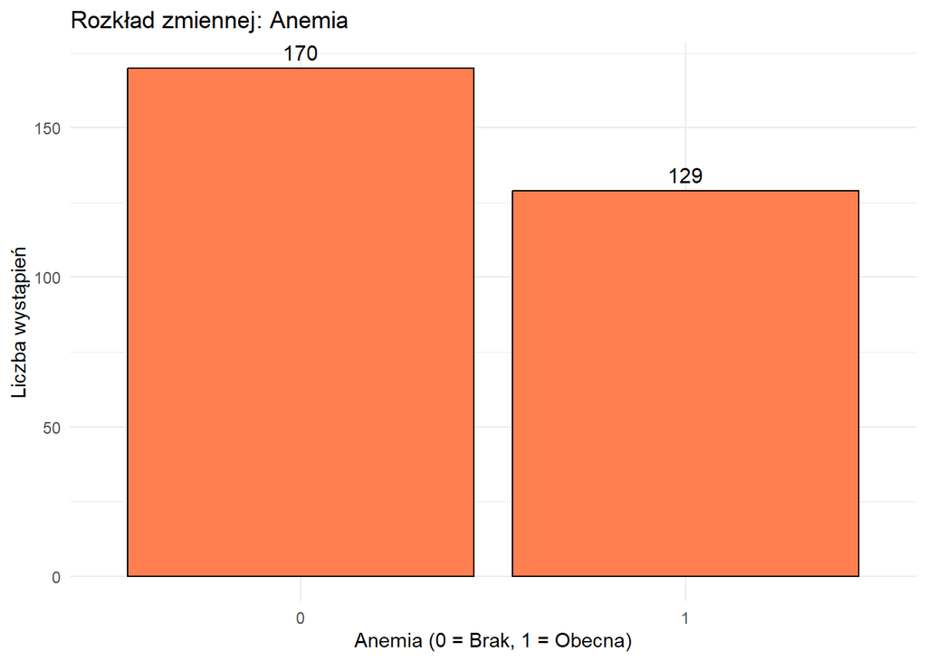

```r
ggplot(data, aes(x = factor(data$anaemia))) +
  geom_bar(fill = "coral", color = "black") +
  geom_text(stat = 'count', aes(label = ..count..), vjust = -0.5, size = 4) +
  labs(title = "Rozkład zmiennej: Anemia", x = "Anemia (0 = Brak, 1 = Obecna)", y = "Liczba wystąpień") +
  theme_minimal()
```

### 3.1.2 Rozkład zmiennej - występowanie cukrzycy;

- **Czy pacjent choruje na cukrzycę (zmienna binarna: 1 = Tak, 0 = Nie)**

Cukrzyca dotyka znaczną część badanej populacji, gdyż około 40% pacjentów cierpi na to schorzenie. Wyniki te wskazują, że cukrzyca może być istotnym czynnikiem ryzyka lub zmienną wpływającą w analizie, szczególnie w połączeniu z innymi zmiennymi, takimi jak wiek, poziom cholesterolu czy anemii. Warto przeprowadzić dalsze analizy, aby zidentyfikować czynniki predykcyjne związane z obecnością cukrzycy w badanej grupie.

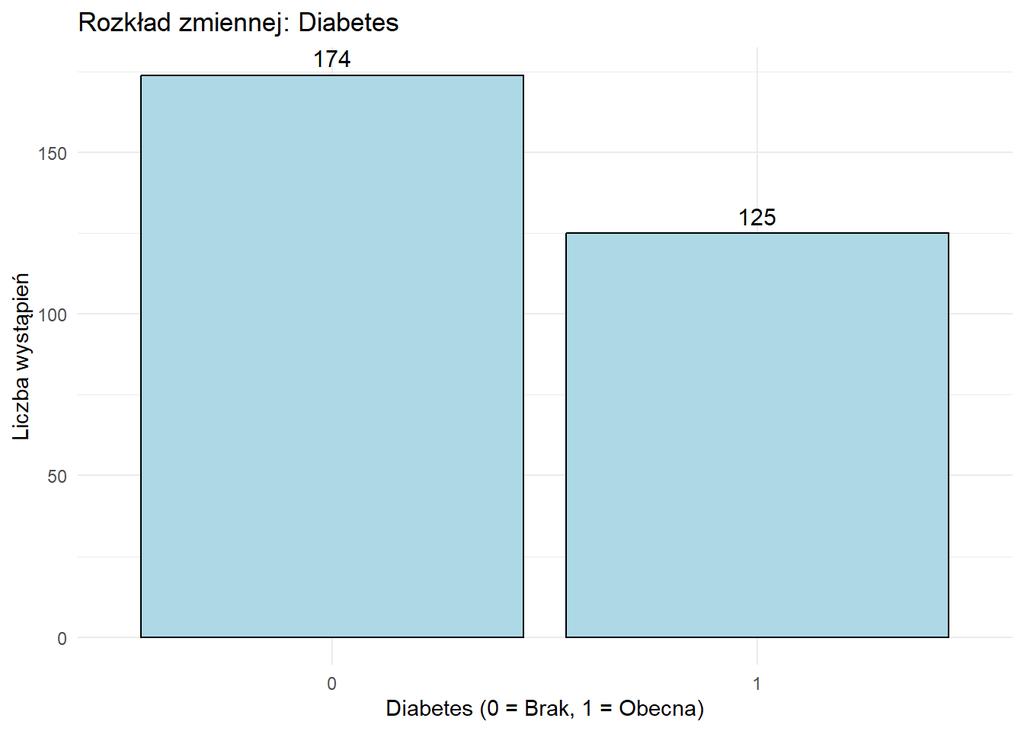

```r
ggplot(data, aes(x = factor(diabetes))) +
  geom_bar(fill = "lightblue", color = "black") +
  geom_text(stat = 'count', aes(label = ..count..), vjust = -0.5, size = 4) +
  labs(title = "Rozkład zmiennej: Diabetes", x = "Diabetes (0 = Brak, 1 = Obecna)", y = "Liczba wystąpień") +
  theme_minimal()
```

### 3.1.3 Rozkład zmiennej - występowanie wysokiego ciśnienia krwi;

**Czy pacjent ma nadciśnienie (zmienna binarna: 1 = Tak, 0 = Nie).** **Jeżeli pacjent choruje na nadciśnienie tętnicze, ryzyko wystąpienia poniższych chorób wzrasta:**

- **Miażdżyca**
- **Choroba niedokrwienna serca**
- **Zawał mięśnia sercowego**

Większość pacjentów nie cierpi na wysokie ciśnienie krwi, jednak około 1/3 badanych ma taki problem. Wynik wskazuje, że wysokie ciśnienie krwi jest istotnym czynnikiem zdrowotnym w tej grupie pacjentów i warto uwzględnić je w dalszych analizach w kontekście innych zmiennych, takich jak wiek, obecność cukrzycy czy poziom cholesterolu.

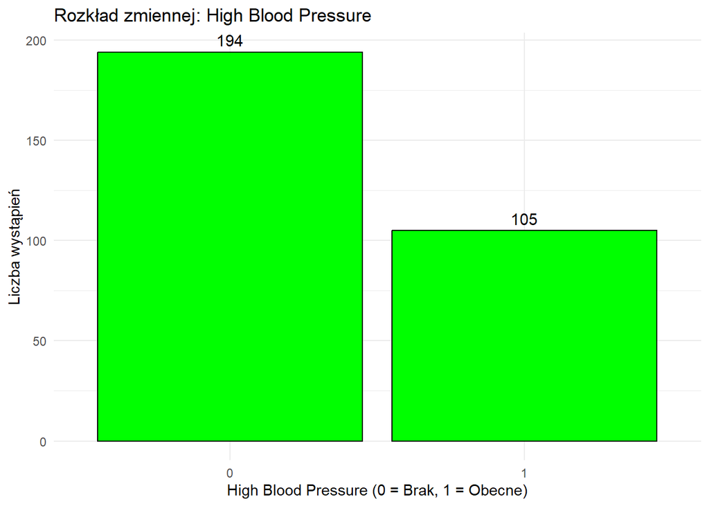

```r
ggplot(data, aes(x = factor(data$high_blood_pressure))) +
  geom_bar(fill = "green", color = "black") +
  geom_text(stat = 'count', aes(label = ..count..), vjust = -0.5, size = 4) +
  labs(title = "Rozkład zmiennej: High Blood Pressure", x = "High Blood Pressure (0 = Brak, 1 = Obecne)", y = "Liczba wystąpień") +
  theme_minimal()
```

### 3.1.4 Rozkład zmiennej płeć;

– **Płeć pacjenta (zmienna binarna: 1 = Mężczyzna, 0 = Kobieta)**

Wyniki wskazują na nierówną reprezentację płci w badaniu, z wyraźną przewagą mężczyzn. Może to być istotne przy interpretacji wyników i analizie zależności, ponieważ różnice w wynikach zdrowotnych mogą być związane z różnicami biologicznymi między płciami. Warto w dalszych analizach sprawdzić, jak płeć wpływa na inne zmienne, takie jak występowanie cukrzycy, wysokiego ciśnienia krwi czy anemii.

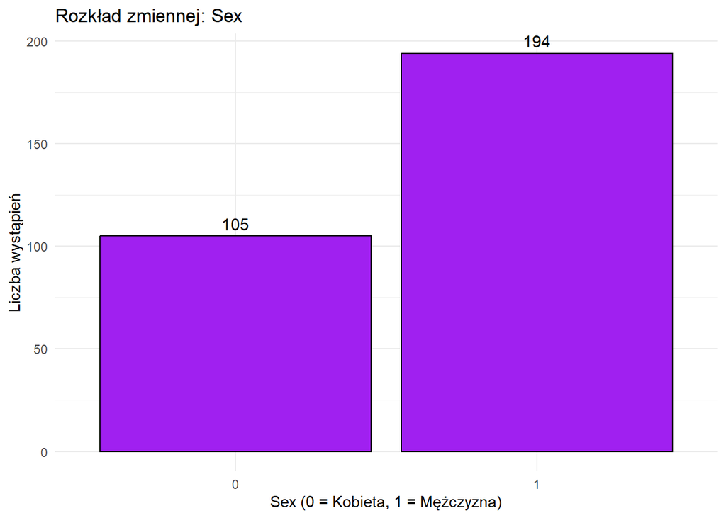

```r
ggplot(data, aes(x = factor(data$sex))) +
  geom_bar(fill = "purple", color = "black") +
  geom_text(stat = 'count', aes(label = ..count..), vjust = -0.5, size = 4) +
  labs(title = "Rozkład zmiennej: Sex", x = "Sex (0 = Kobieta, 1 = Mężczyzna)", y = "Liczba wystąpień") +
  theme_minimal()
```

### 3.1.5 Rozkład zmiennej palenie;

– **Czy pacjent pali (zmienna binarna: 1 = Tak, 0 = Nie).** – **Najczęstszym nowotworem u obu płci jest nowotwór płuc, więc osoby palące są bardziej narażone.**

Wyniki sugerują, że większość badanej populacji nie pali, co może wpływać pozytywnie na ich zdrowie. Osoby palące stanowią jednak istotną grupę, którą warto uwzględnić w dalszych analizach, szczególnie w kontekście wpływu palenia na inne zmienne, takie jak występowanie chorób sercowo-naczyniowych, wysokiego ciśnienia czy anemii.

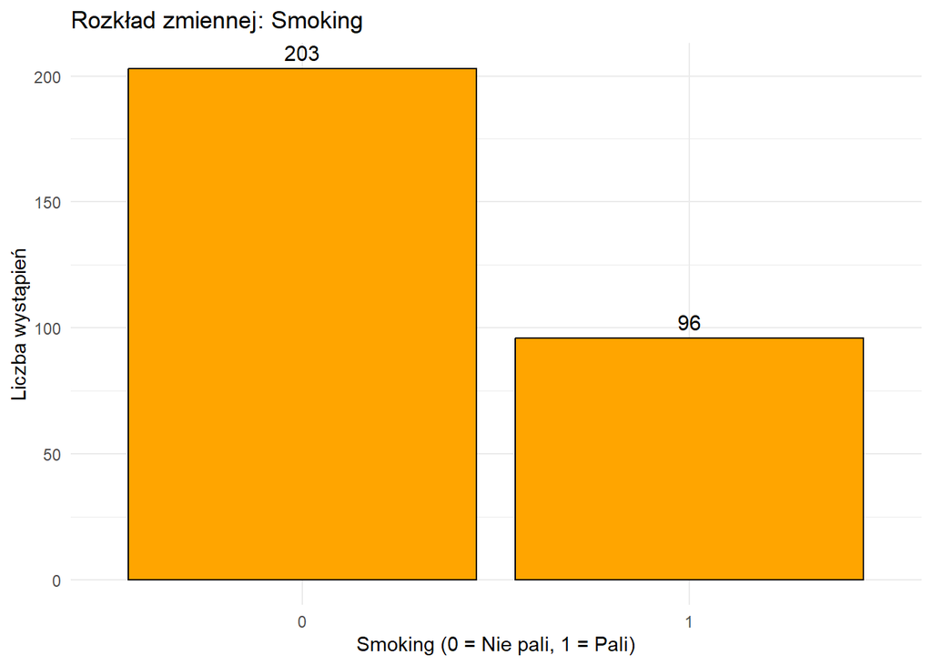

```r
ggplot(data, aes(x = factor(data$smoking))) +
  geom_bar(fill = "orange", color = "black") +
  geom_text(stat = 'count', aes(label = ..count..), vjust = -0.5, size = 4) +
  labs(title = "Rozkład zmiennej: Smoking", x = "Smoking (0 = Nie pali, 1 = Pali)", y = "Liczba wystąpień") +
  theme_minimal()
```

### 3.1.6 Rozkład zmiennej - Zdarzenie śmierci

- **Zdarzenie śmierci jest zmienną objaśnianą**

Większość badanych pacjentów przeżyła, jednak odsetek pacjentów, którzy zmarli (około 32%), jest istotny w kontekście analiz. Dalsze badania mogą skupić się na identyfikacji czynników ryzyka, takich jak wiek, anemia, cukrzyca czy poziom cholesterolu, które mogły wpłynąć na zwiększone ryzyko zgonu.

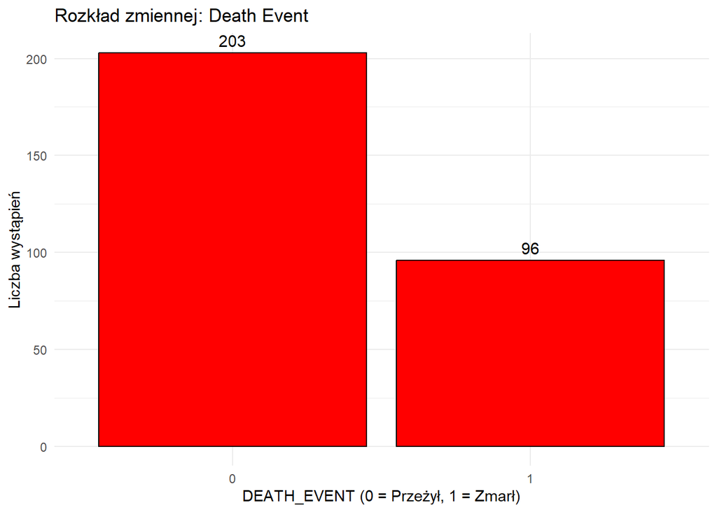

```r
ggplot(data, aes(x = factor(data$DEATH_EVENT))) +
  geom_bar(fill = "red", color = "black") +
  geom_text(stat = 'count', aes(label = ..count..), vjust = -0.5, size = 4) +
  labs(title = "Rozkład zmiennej: Death Event", x = "DEATH_EVENT (0 = Przeżył, 1 = Zmarł)", y = "Liczba wystąpień") +
  theme_minimal()
```

## 3.2 Rozkłady zmiennych w skali nominalnej

### 3.2.1 Rozkład zmiennej: Wiek - wiek pacjenta wyrażony w latach

**Dominujące grupy wiekowe:**

Najliczniejszą grupę stanowią pacjenci w przedziale wieku około 60-70 lat, gdzie najwyższy słupek osiąga wartość około 40 osób. Widać również mniejsze grupy pacjentów w młodszych przedziałach wiekowych, szczególnie w przedziale 40-50 lat.

**Rozkład wieku:**

Rozkład zmiennej wiek jest asymetryczny, z większą liczbą pacjentów w starszych grupach wiekowych. Liczba pacjentów maleje w miarę przesuwania się do skrajnie młodych lub bardzo starych przedziałów wiekowych.

**Skrajne wartości:**

**Podsumowanie:**

Rozkład wieku pacjentów wskazuje, że większość osób w badanej próbie to osoby w średnim i starszym wieku, z dominacją przedziału 60-70 lat. Warto zwrócić uwagę na wpływ wieku na inne zmienne, takie jak występowanie chorób przewlekłych (np. wysokiego ciśnienia, cukrzycy) lub zgonów.

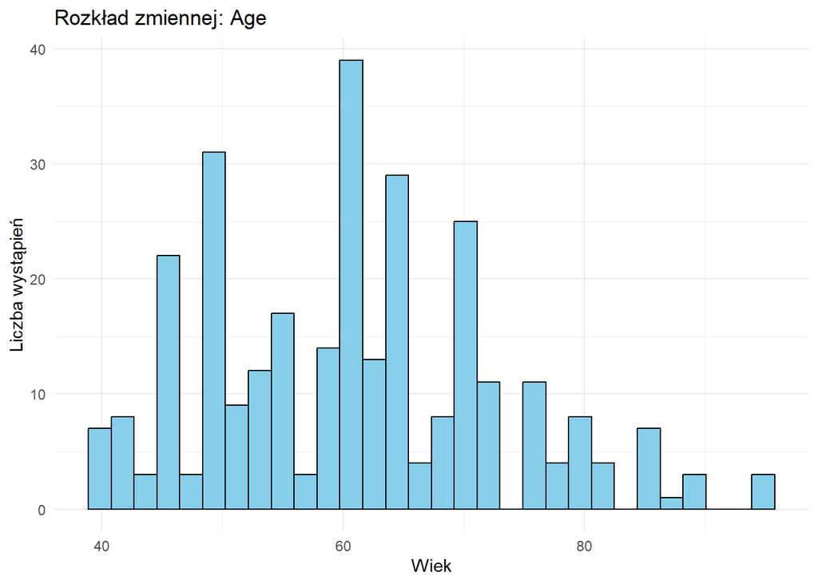

```r
ggplot(data, aes(x = as.numeric(data$age))) +
  geom_histogram(fill = "skyblue", color = "black", bins = 30) +
  labs(title = "Rozkład zmiennej: Age", x = "Wiek", y = "Liczba wystąpień") +
  theme_minimal()
```

### 3.2.2 Rozkład zmiennej - poziom enzymu CPK we krwi

**Asymetria prawostronna:**

Rozkład zmiennej charakteryzuje się silną asymetrią prawostronną, co oznacza, że większość pacjentów ma stosunkowo niskie wartości poziomu CPK, a tylko nieliczni mają znacznie wyższe poziomy.

**Dominujące wartości:**

Większość pacjentów ma poziom CPK w przedziale 0–500 jednostek. Liczba pacjentów z wyższymi wartościami (np. powyżej 2000 jednostek) gwałtownie maleje, co wskazuje na rzadkość występowania tak wysokich poziomów.

**Ekstremalne wartości:**

Występują pojedyncze przypadki z poziomem CPK przekraczającym 4000–8000 jednostek, które są znacząco wyższe od wartości typowych dla większości pacjentów. Mogą one wskazywać na szczególne przypadki kliniczne, takie jak poważne uszkodzenia mięśni lub zawał serca.

**Podsumowanie:**

Rozkład poziomu enzymu CPK w badanej próbie jest wyraźnie asymetryczny, z dominacją niskich wartości. Ekstremalnie wysokie wartości, choć rzadkie, mogą być związane z istotnymi problemami zdrowotnymi. Warto przeanalizować związek wysokiego poziomu CPK z innymi zmiennymi, np. występowaniem zawału, wysokiego ciśnienia krwi czy zgonów.

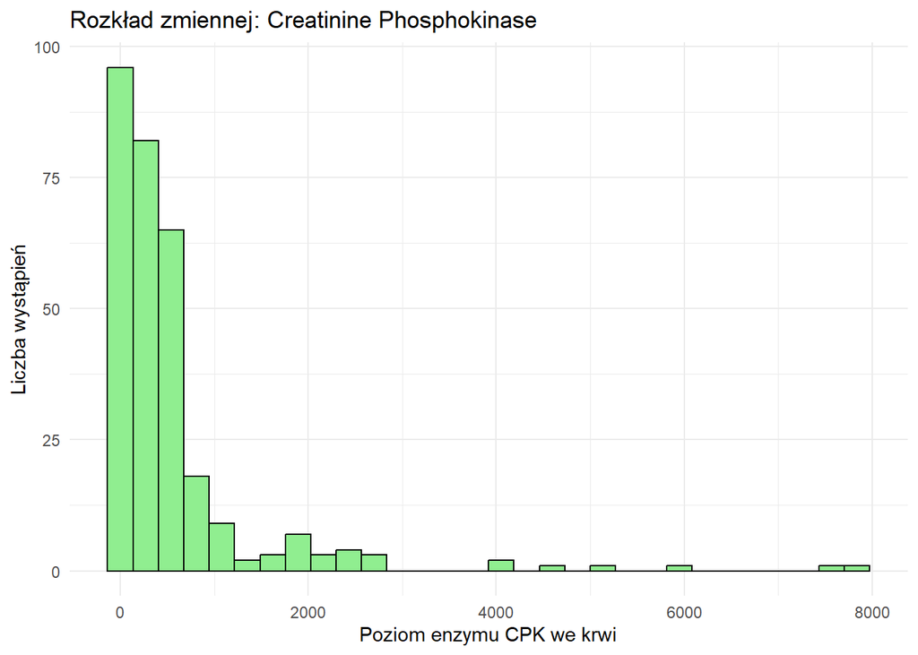

```r
ggplot(data, aes(x = as.numeric(data$creatinine_phosphokinase))) +
  geom_histogram(fill = "lightgreen", color = "black", bins = 30) +
  labs(title = "Rozkład zmiennej: Creatinine Phosphokinase", x = "Poziom enzymu CPK we krwi", y = "Liczba wystąpień") +
  theme_minimal()
```

### 3.2.3 Rozkład zmiennej - Procent krwi wypompowywanej z serca

- **Procent krwi wypompowywanej z serca przy każdym skurczu wyrażony jako liczba całkowita w zakresie (0;100)**

**Dominujące wartości frakcji wyrzutowej:**

Największa liczba pacjentów ma frakcję wyrzutową w przedziale 30-50%, z najwyższym pikiem w okolicach 40%. Średnia wartość frakcji wyrzutowej znajduje się w tym zakresie, co wskazuje na typowy poziom funkcji serca w tej grupie badawczej.

**Rzadkość ekstremalnych wartości:**

Bardzo niskie wartości frakcji wyrzutowej (poniżej 20%) oraz bardzo wysokie wartości (powyżej 60%) są stosunkowo rzadkie. Wartości powyżej 70% są niemal nieobecne w badanej próbie, co potwierdza, że są one nietypowe.

**Rozkład zmiennej:**

Rozkład zmiennej jest lekko asymetryczny z przesunięciem w kierunku niższych wartości, co może wynikać z obecności pacjentów z upośledzoną funkcją serca.

**Podsumowanie:**

Frakcja wyrzutowa większości pacjentów mieści się w przedziale 30-50%, co może wskazywać na grupę z zaburzeniami funkcji serca, ponieważ prawidłowa frakcja wyrzutowa wynosi zwykle powyżej 50%. Ekstremalnie niskie wartości (<20%) mogą sugerować poważne problemy kardiologiczne, podczas gdy bardzo wysokie wartości są rzadkie.

W dalszych analizach warto zbadać, jak frakcja wyrzutowa koreluje z innymi zmiennymi, takimi jak obecność zgonów, anemii czy cukrzycy.

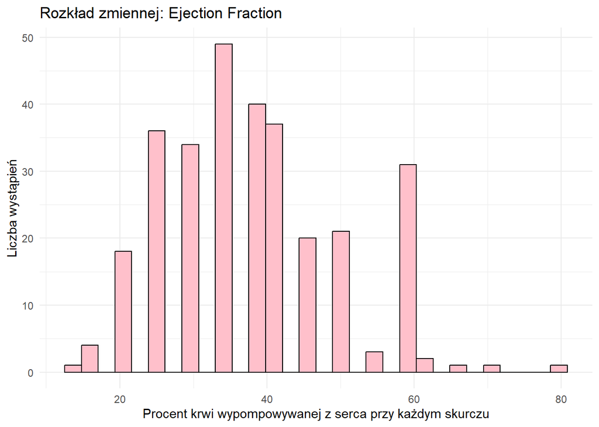

```r
ggplot(data, aes(x = as.numeric(data$ejection_fraction))) +
  geom_histogram(fill = "pink", color = "black", bins = 30) +
  labs(title = "Rozkład zmiennej: Ejection Fraction", x = "Procent krwi wypompowywanej z serca przy każdym skurczu", y = "Liczba wystąpień") +
  theme_minimal()
```

### 3.2.4 Rozkład zmiennej - Liczba płytek krwi

- **Jeżeli wartość jest niska, mogą występować krwawienia.**
- **Jeżeli jest duża to zakrzepy. Z zakrzepów może powstać zator, będący przyczyną zatorowości płucnej.**

**Dominujące wartości liczby płytek krwi:**

Większość pacjentów ma liczbę płytek krwi w zakresie od 200 000 do 300 000. Największa liczba pacjentów znajduje się w okolicach 250 000, co stanowi wartość bliską średniej w tej populacji.

**Rozkład zmiennej:**

Rozkład zmiennej jest lekko asymetryczny, z tendencją do występowania niższych wartości w porównaniu z typowymi zakresami. Pacjenci z bardzo wysoką liczbą płytek krwi (powyżej 600 000) są rzadkością i stanowią odległe obserwacje.

**Ekstremalne wartości:**

Obserwuje się pojedyncze przypadki, gdzie liczba płytek krwi przekracza 750 000, co może sugerować potencjalne problemy zdrowotne, takie jak zwiększona skłonność do zakrzepicy.

**Podsumowanie:** Rozkład liczby płytek krwi jest skoncentrowany w typowym zakresie (200 000–300 000), co jest zgodne z normami dla zdrowej populacji. Rzadkie przypadki ekstremalnie wysokich wartości (powyżej 600 000) mogą wskazywać na zwiększone ryzyko zakrzepicy, co warto uwzględnić w dalszej analizie.

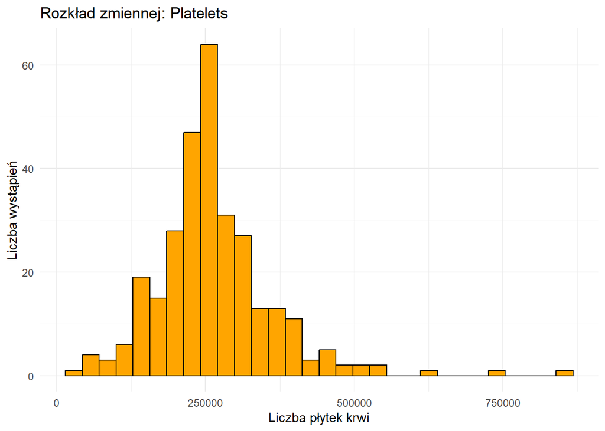

```r
ggplot(data, aes(x = as.numeric(data$platelets))) +
  geom_histogram(fill = "orange", color = "black", bins = 30) +
  labs(title = "Rozkład zmiennej: Platelets", x = "Liczba płytek krwi", y = "Liczba wystąpień") +
  theme_minimal()
```

### 3.2.5 Rozkład zmiennej - Poziom kreatyniny w surowicy krwi.

- **Wysoki poziom kreatyniny, wskazuje na niewydolność nerek.**

**Dominujące wartości poziomu kreatyniny:**

Większość pacjentów ma poziom kreatyniny skoncentrowany w przedziale 0–1 mg/dl, co wskazuje na prawidłową funkcję nerek w tej grupie. Największa liczba pacjentów ma poziom kreatyniny bliski wartości 1 mg/dl.

**Ekstremalne wartości:**

Kilka pacjentów ma poziom kreatyniny powyżej 2 mg/dl, a wartości w zakresie 5–10 mg/dl występują niezwykle rzadko. Te wysokie wartości mogą wskazywać na poważne zaburzenia czynności nerek.

**Rozkład zmiennej:**

Rozkład zmiennej jest silnie asymetryczny prawostronnie, co oznacza, że znaczna większość pacjentów ma niskie wartości kreatyniny, a jedynie niewielka liczba ma wartości znacznie podwyższone.

**Podsumowanie:**

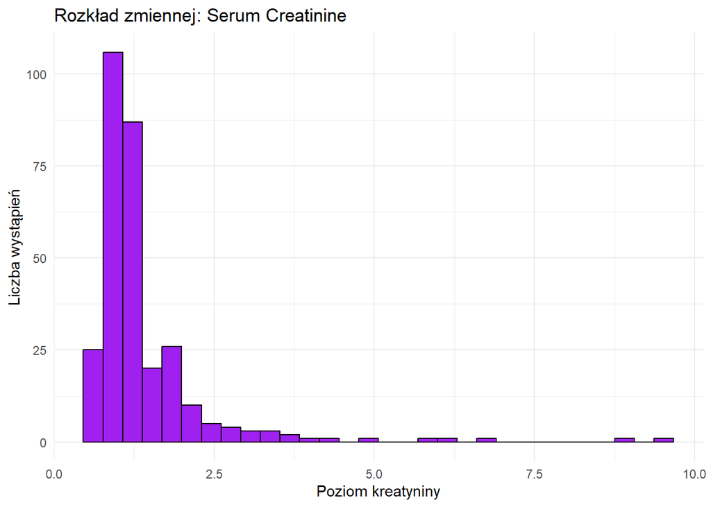

```r
ggplot(data, aes(x = as.numeric(data$serum_creatinine))) +
  geom_histogram(fill = "purple", color = "black", bins = 30) +
  labs(title = "Rozkład zmiennej: Serum Creatinine", x = "Poziom kreatyniny", y = "Liczba wystąpień") +
  theme_minimal()
```

### 3.2.6 Rozkład zmiennej - poziom sodu w surowicy krwi

- **Niski poziom sodu może być wskaźnikiem niewydolności serca.**

**Dominujące wartości poziomu sodu:**

Najwięcej pacjentów ma poziom sodu w przedziale 135-145 mmol/l, co jest zgodne z zakresem uznawanym za normę dla zdrowych osób. Wartość najczęściej występująca to około 140 mmol/l.

**Rzadkie przypadki niskiego poziomu sodu:**

Wartości poniżej 130 mmol/l, które mogą wskazywać na niedobór sodu (hiponatremia), występują rzadko. Tego rodzaju obserwacje mogą wskazywać na niewydolność serca lub inne zaburzenia metaboliczne.

**Rozkład zmiennej:**

**Podsumowanie:**

Poziom sodu w surowicy krwi większości pacjentów mieści się w normie (135-145 mmol/l), co sugeruje brak zaburzeń elektrolitowych u dużej części grupy. Nieliczne przypadki hiponatremii mogą wskazywać na poważniejsze problemy zdrowotne, takie jak niewydolność serca.

Warto zbadać korelację między niskim poziomem sodu a innymi zmiennymi, takimi jak występowanie zgonów czy zaburzeń metabolicznych.

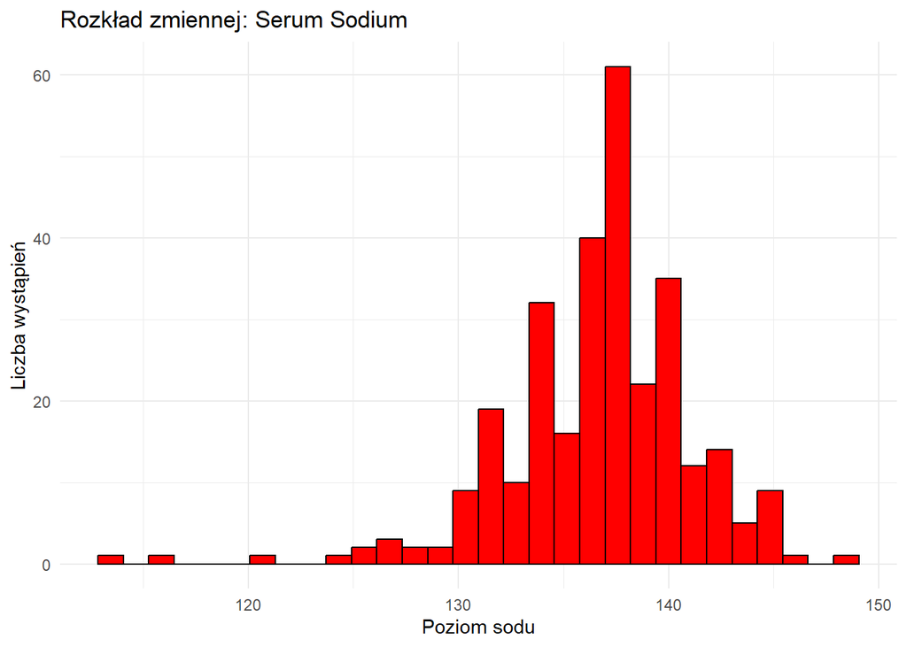

```r
ggplot(data, aes(x = as.numeric(data$serum_sodium))) +
  geom_histogram(fill = "red", color = "black", bins = 30) +
  labs(title = "Rozkład zmiennej: Serum Sodium", x = "Poziom sodu", y = "Liczba wystąpień") +
  theme_minimal()
```

### 3.2.7 Rozkład zmiennej czas - okres obserwacji w dniach

**Dominujące okresy obserwacji:**

**Różnorodność w czasie obserwacji:**

Okresy obserwacji są rozłożone stosunkowo równomiernie w badanej grupie, co oznacza, że próba zawiera zarówno pacjentów z krótką, jak i dłuższą obserwacją. Wartości bliższe końcowi okresu (powyżej 250 dni) występują rzadziej.

**Rozkład zmiennej:**

Rozkład zmiennej jest rozproszony, bez wyraźnej koncentracji w jednym przedziale, co może sugerować różnorodne okresy monitorowania w zależności od stanu zdrowia pacjentów.

**Podsumowanie:**

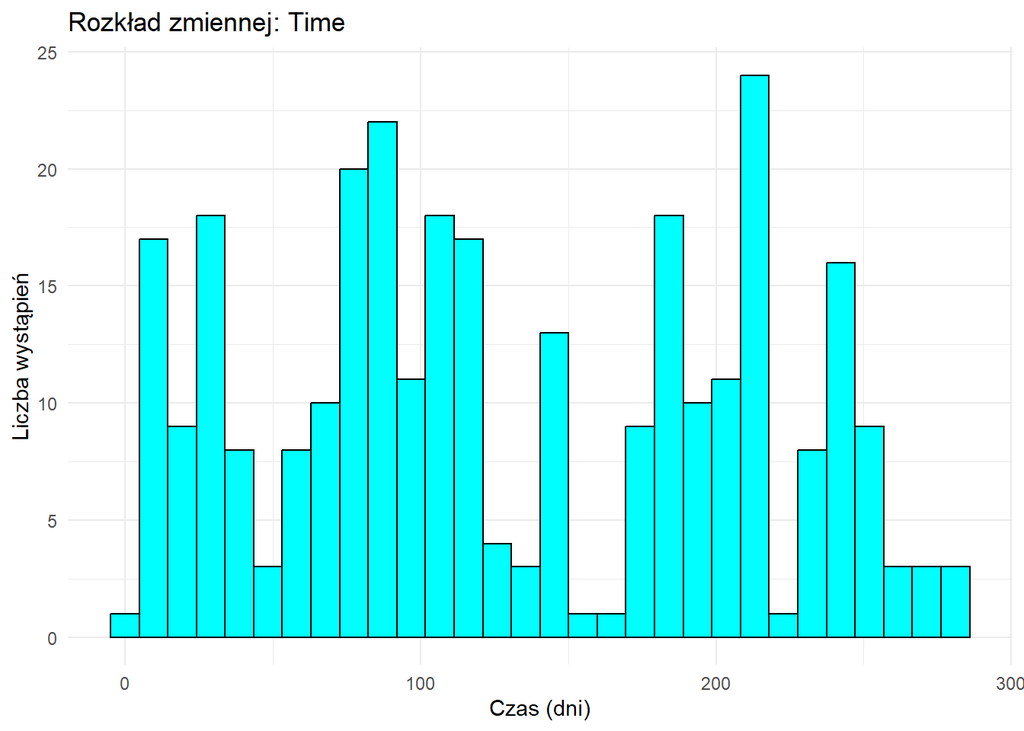

```r
ggplot(data, aes(x = as.numeric(data$time))) +
  geom_histogram(fill = "cyan", color = "black", bins = 30) +
  labs(title = "Rozkład zmiennej: Time", x = "Czas (dni)", y = "Liczba wystąpień") +
  theme_minimal()
```

## 3.3 Wykres pokazujący korelacje pomiędzy zmiennymi ilościowymi

**Silne korelacje:**

**Słabe lub brak korelacji:**

creatinine_phosphokinase z innymi zmiennymi: Enzym CPK nie wykazuje silnych korelacji z innymi zmiennymi, co może wskazywać, że jego poziom jest niezależny od tych czynników. age z pozostałymi zmiennymi: Wiek nie wydaje się być silnie skorelowany z żadną z pozostałych zmiennych.

**Dodatnie korelacje:**

serum_sodium i ejection_fraction: Obserwuje się słabą dodatnią korelację, co może wskazywać, że wyższy poziom sodu jest związany z lepszą funkcją serca.

**Podsumowanie:**

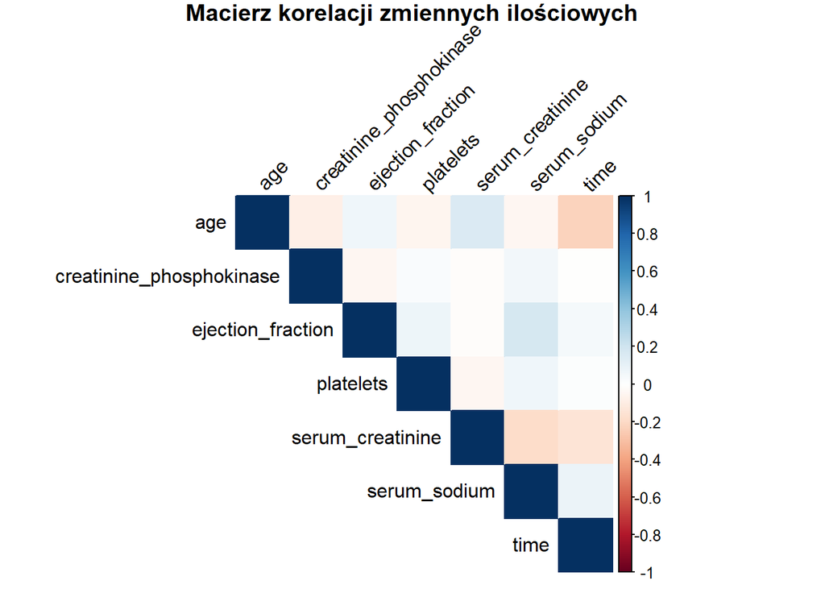

```r
zmienne_numeryczne <- data[, c("age", "creatinine_phosphokinase", "ejection_fraction",
                         "platelets", "serum_creatinine", "serum_sodium", "time")]

zmienne_numeryczne <- as.data.frame(lapply(zmienne_numeryczne, as.numeric))

macierz_kor_zm_numerycznych <- cor(zmienne_numeryczne, use = "complete.obs", method = "pearson")

corrplot(macierz_kor_zm_numerycznych, method = "color", type = "upper",
         tl.col = "black", tl.srt = 45, title = "Macierz korelacji zmiennych ilościowych", mar = c(0, 0, 1, 0))
```

# 4 Statystyki względem płci zmiennych ilościowych

```r
zmienne_numeryczne <- c("age", "creatinine_phosphokinase", "ejection_fraction",
                        "platelets", "serum_creatinine", "serum_sodium", "time")

data[zmienne_numeryczne] <- lapply(data[zmienne_numeryczne], as.numeric)

# Obliczanie statystyk w rozróżnieniu na płeć
statystyki_ilosciowe <- data %>%
  group_by(sex) %>%
  summarise(across(all_of(zmienne_numeryczne),
    list(
      N = ~sum(!is.na(.x)),  # Liczba obserwacji bez NA
      Mean = ~mean(.x, na.rm = TRUE),
      Min = ~min(.x, na.rm = TRUE),
      Max = ~max(.x, na.rm = TRUE),
      Sd = ~sd(.x, na.rm = TRUE)
    ), .names = "{.col}_{.fn}"))

statystyki_ilosciowe %>%
  kable(format = "html", caption = "Statystyki opisowe w rozróżnieniu na płeć") %>%
  kable_styling(full_width = FALSE, bootstrap_options = c("striped", "hover", "condensed", "responsive"))
```

Statystyki opisowe w rozróżnieniu na płeć

| sex | age_N | age_Mean | age_Min | age_Max | age_Sd | creatinine_phosphokinase_N | creatinine_phosphokinase_Mean | creatinine_phosphokinase_Min | creatinine_phosphokinase_Max | creatinine_phosphokinase_Sd | ejection_fraction_N | ejection_fraction_Mean | ejection_fraction_Min | ejection_fraction_Max | ejection_fraction_Sd | platelets_N | platelets_Mean | platelets_Min | platelets_Max | platelets_Sd | serum_creatinine_N | serum_creatinine_Mean | serum_creatinine_Min | serum_creatinine_Max | serum_creatinine_Sd | serum_sodium_N | serum_sodium_Mean | serum_sodium_Min | serum_sodium_Max | … |
| --- | --- | --- | --- | --- | --- | --- | --- | --- | --- | --- | --- | --- | --- | --- | --- | --- | --- | --- | --- | --- | --- | --- | --- | --- | --- | --- | --- | --- | --- | --- |
| 0 | 105 | 59.77778 | 40 | 95 | 11.24092 | 105 | 476.781 | 52 | 3964 | 611.3642 | 105 | 40.46667 | 15 | 80 | 12.72873 | 105 | 279964.0 | 62000 | 742000 | 102108.75 | 105 | 1.384095 | 0.5 | 9.0 | 1.1186330 | 105 | 136.7905 | 116 | 146 | … |
| 1 | 194 | 61.40550 | 40 | 95 | 12.22442 | 194 | 638.701 | 23 | 7861 | 1114.8940 | 194 | 36.79381 | 14 | 62 | 11.14431 | 194 | 254370.2 | 25100 | 850000 | 94447.36 | 194 | 1.399175 | 0.6 | 9.4 | 0.9889757 | 194 | 136.5361 | 113 | 148 | … |

# 5 Statystyki względem płci dla zmiennych binarnych

```r
zmienne_jakosciowe <- c("anaemia", "diabetes", "high_blood_pressure", "smoking", "DEATH_EVENT")

statystyki_jakosciowe <- data %>%
  group_by(sex) %>%
  summarise(across(all_of(zmienne_jakosciowe),
                   ~paste0(sum(.x == 1, na.rm = TRUE), "/", sum(.x == 0, na.rm = TRUE)),
                   .names = "{.col}_counts")) %>%
  ungroup()

statystyki_jakosciowe %>%
  kable(format = "html", caption = "Liczebność zmiennych jakościowych w rozróżnieniu na płeć") %>%
  kable_styling(full_width = FALSE, bootstrap_options = c("striped", "hover", "condensed", "responsive"))
```

Liczebność zmiennych jakościowych w rozróżnieniu na płeć

| sex | anaemia_counts | diabetes_counts | high_blood_pressure_counts | smoking_counts | DEATH_EVENT_counts |
| --- | --- | --- | --- | --- | --- |
| 0 | 52/53 | 55/50 | 44/61 | 4/101 | 34/71 |
| 1 | 77/117 | 70/124 | 61/133 | 92/102 | 62/132 |

# 6 Funkcja czasu trwania oraz skumulowanego hazardu

## 6.1 Kaplan-Meier

**Początkowe prawdopodobieństwo przeżycia:**

Na początku okresu obserwacji (czas = 0) prawdopodobieństwo przeżycia wynosi 1.0 (100%), co oznacza, że wszystkie osoby na początku badania żyją.

**Spadek funkcji przeżycia w czasie:**

Funkcja przeżycia systematycznie maleje, co wskazuje na kolejne zgony pacjentów w czasie trwania badania. Największe spadki widoczne są w pierwszych 100 dniach oraz w okolicach 150–200 dni, co sugeruje, że w tych okresach zmarła większa liczba pacjentów.

**Asymptota w końcowym okresie:**

Po 250 dniach krzywa przeżycia staje się płaska. Oznacza to, że w końcowym okresie obserwacji zgony stają się rzadsze, a prawdopodobieństwo przeżycia stabilizuje się.

**Przedział ufności (linie przerywane):**

Linie przerywane wokół głównej krzywej reprezentują 95% przedział ufności, pokazując niepewność oszacowań. Na początku przedział jest wąski (duża liczba osób w badaniu), ale wraz z czasem staje się szerszy (mniejsza liczba osób pozostających w badaniu).

**Ogólne wnioski:**

W badanej grupie widoczny jest spadek przeżycia w czasie, co może wskazywać na obecność czynników ryzyka zwiększających śmiertelność (np. choroby przewlekłe). Znaczny spadek funkcji przeżycia w pierwszych 150 dniach może sugerować, że większość zgonów w badanej grupie miała miejsce w początkowym okresie obserwacji. Przetrwanie w dłuższym okresie (powyżej 200 dni) staje się bardziej stabilne, ponieważ krzywa przeżycia wyrównuje się.

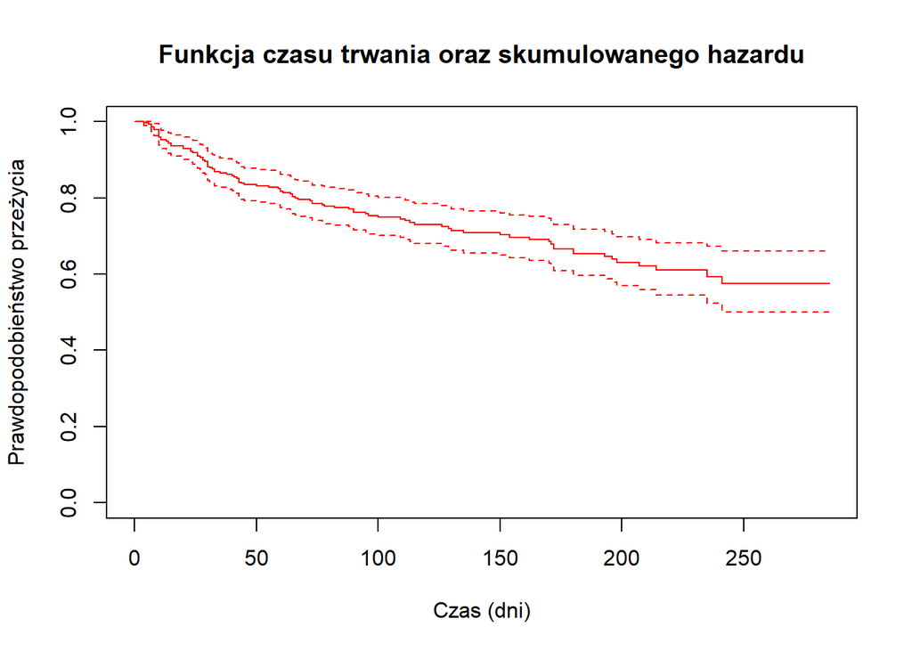

```r
plot(km,
     main="Funkcja czasu trwania oraz skumulowanego hazardu",
     xlab="Czas (dni)",
     ylab="Prawdopodobieństwo przeżycia")
lines(km,col="red")
```

## 6.2 Nelson-Aalen

**Prawdopodobieństwo przeżycia w czasie:**

**Przyspieszenie prawdopodobieństwa przeżycia:**

**Przedziały ufności:**

Linie przerywane wokół głównej linii reprezentują 95% przedział ufności, który obrazuje niepewność oszacowań skumulowanego hazardu. Wraz z upływem czasu przedziały stają się szersze, co wynika z malejącej liczby pacjentów pozostających pod obserwacją.

**Podsumowanie:**

Prawdopdoobieństwo przeżycia maleje w czasie, co wskazuje na kumulowanie się ryzyka zdarzeń (np. zgonów) w badanej grupie. Największy spadek prawdobieństwa przeżycia obserwuje się w początkowym okresie badania, co sugeruje, że większość zdarzeń miała miejsce w pierwszych 100-150 dniach obserwacji. Końcowa stabilizacja prawdobobieństwa przeżycia może wynikać z mniejszej liczby pacjentów lub poprawy ich stanu zdrowia w dłuższym okresie.

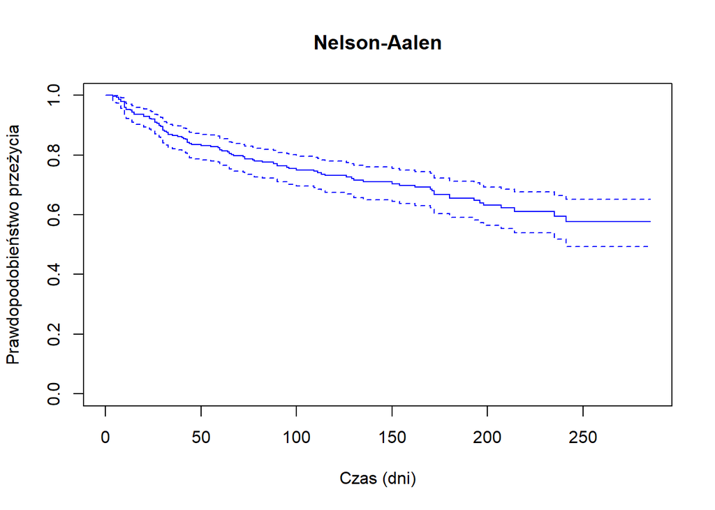

```r
# Analiza metodą Nelson-Aalen
Nels <- survfit(Surv(data$time, data$DEATH_EVENT) ~ 1, conf.type = "log-log", type = "fleming-harrington", data = data)
summary(Nels)  # Wyświetlenie szczegółów analizy
plot(Nels,
     main="Nelson-Aalen",
     xlab="Czas (dni)",
     ylab="Prawdopodobieństwo przeżycia")     # Wykres krzywej przeżycia
lines(Nels, col = "blue")  # Dodanie linii na wykresie
```

[output not shown]

## 6.3 Krzywe przeżycia według płci

W tym wypadku nawiązuje tylko do badania statystyk dla obu płci.

**Początkowe prawdopodobieństwo przeżycia:**

Zarówno kobiety (linia czerwona), jak i mężczyźni (linia niebieska) rozpoczynają badanie z prawdopodobieństwem przeżycia równym 1.0 (100%), co oznacza, że wszyscy uczestnicy badania żyją na początku obserwacji.

**Spadek prawdopodobieństwa przeżycia:**

W obu grupach widoczny jest systematyczny spadek prawdopodobieństwa przeżycia w czasie, co wskazuje na zgony w obu grupach w trakcie trwania badania. Największe spadki w obu grupach występują w pierwszych 150 dniach.

**Porównanie między płciami:**

Krzywe przeżycia dla kobiet i mężczyzn są bardzo podobne, co wskazuje na brak istotnych różnic w prawdopodobieństwie przeżycia między płciami. Minimalne różnice są widoczne w niektórych punktach, np. w okolicach 100-150 dni, gdzie prawdopodobieństwo przeżycia dla mężczyzn jest odrobinę wyższe.

**Końcowa stabilizacja:**

Po około 250 dniach krzywe przeżycia stają się płaskie w obu grupach, co oznacza brak dalszych zgonów w końcowej fazie obserwacji. Podsumowanie Krzywe przeżycia kobiet i mężczyzn są do siebie zbliżone, co sugeruje, że płeć nie jest istotnym czynnikiem różnicującym przeżycie w tej populacji. Obserwowane zgony koncentrują się głównie w pierwszych 150 dniach obserwacji.

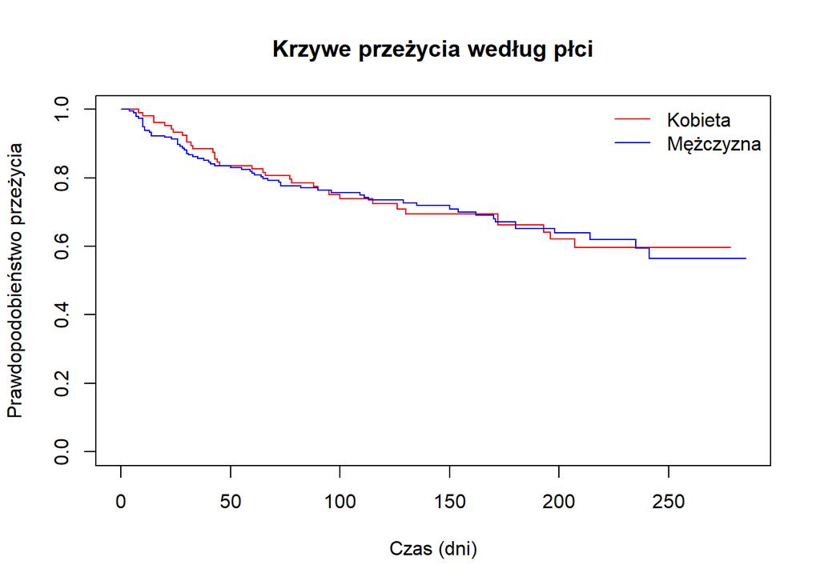

```r
Sex = survfit(Surv(data$time, data$DEATH_EVENT) ~ sex, data = data,
              conf.type = "none", type = "fleming-harrington")

plot(Sex, col = c("red", "blue"),
     main = "Krzywe przeżycia według płci",
     xlab = "Czas (dni)",
     ylab = "Prawdopodobieństwo przeżycia")

legend("topright", c("Kobieta", "Mężczyzna"),
       lty = 1, col = c("red", "blue"), bty = "n")
```

## 6.4 Krzywa przeżycia w zależności od obecności cukrzycy

**Interpretacja:**

- Hipoteza zerowa (H0): Nie ma różnic w przeżywalności między grupą pacjentów z cukrzycą a grupą bez cukrzycy.

**Statystyka testu:**

- Statystyka chi-kwadrat wynosi 0, co wskazuje na brak różnic między obserwowanymi a oczekiwanymi zdarzeniami w obu grupach.
- P-wartość: p=0.8
- p=0.8 oznacza, że nie ma statystycznych podstaw do odrzucenia hipotezy zerowej. P-wartość jest znacznie większa niż typowy poziom istotności (np. 0,05).

**Wniosek:** - Nie stwierdzono istotnych różnic w przeżywalności między pacjentami z cukrzycą a osobami bez cukrzycy. - Wyniki sugerują, że obecność cukrzycy nie wpływa znacząco na czas przeżycia w analizowanej grupie badawczej.

```r
# Załaduj pakiet survival
library(survival)

# Definicja zmiennej przeżycia i zmiennej grupującej
surv_diabetes <- Surv(data$time, data$DEATH_EVENT) ~ data$diabetes

# Test log-rank
log_rank_test <- survdiff(Surv(data$time, data$DEATH_EVENT) ~ diabetes, data = data)

# Wyświetl wyniki
print(log_rank_test)
```

```
## Call:
## survdiff(formula = Surv(data$time, data$DEATH_EVENT) ~ diabetes,
##     data = data)
##
##              N Observed Expected (O-E)^2/E (O-E)^2/V
## diabetes=0 174       56       55    0.0172    0.0405
## diabetes=1 125       40       41    0.0231    0.0405
##
##  Chisq= 0  on 1 degrees of freedom, p= 0.8
```

**Początkowe prawdopodobieństwo przeżycia:**

Na początku obserwacji (czas = 0 dni) obie grupy rozpoczynają z prawdopodobieństwem przeżycia wynoszącym 1.0 (100%).

**Spadek prawdopodobieństwa przeżycia:**

**Porównanie między grupami:**

**Końcowa stabilizacja:**

[figure not shown]

```r
summary(data$diabetes)

data$diabetes <- as.factor(data$diabetes)

surv_diabetes = survfit(Surv(data$time, data$DEATH_EVENT) ~ data$diabetes, data=data)
summary(surv_diabetes)

plot(surv_diabetes, col = c("orange2", "aquamarine3"), main = "Krzywe przeżycia w zależności od obecności cukrzyczy", xlab = "Czas", ylab = "Prawdopodobieństwo przeżycia", lwd = 2)
legend("topright", legend = c("Diabetycy", "Osoby niechorujące na cukrzycę"),
       lty = 1, col = c("orange2", "aquamarine3"), bty = "n", lwd = 2)
```

[output not shown]

```r
a <- ten(surv_diabetes)
comp(a, p = c(0,1,1,0.5,0.5), q = c(1,0,1,0.5,2))
b <- attr(a, "tft")
print(cbind(b$tft$W, b$tft$pNorm))
```

[output not shown]

## 6.5 Krzywe przeżycia w zależności od obecności nadciśnienia tętniczego

**Początkowe prawdopodobieństwo przeżycia:**

Obie grupy rozpoczynają obserwację z prawdopodobieństwem przeżycia wynoszącym 1.0 (100%), co oznacza, że na początku badania wszyscy pacjenci żyją.

**Spadek prawdopodobieństwa przeżycia:**

W obu grupach obserwuje się stopniowy spadek prawdopodobieństwa przeżycia w czasie, ale przebieg krzywych jest bardzo zbliżony. W początkowej fazie obserwacji różnice między grupami są minimalne.

**Porównanie między grupami:**

**Końcowa stabilizacja:**

W końcowej fazie obserwacji (po 250 dniach) krzywe przeżycia stabilizują się, co oznacza brak dalszych zgonów w badaniu.

**Podsumowanie:**

[figure not shown]

```r
summary(data$high_blood_pressure)

data$high_blood_pressure <- as.factor(data$high_blood_pressure)

surv_high_blood_pressure = survfit(Surv(data$time, data$DEATH_EVENT) ~ data$smoking, data=data)
summary(surv_high_blood_pressure)

plot(surv_high_blood_pressure, col = c("red1", "blue"), main = "Krzywe przeżycia w zależności od posiadania nadciśnienia tętniczego", xlab = "Czas", ylab = "Prawdopodobieństwo przeżycia", lwd = 2)
legend("topright", legend = c("Osoby chorujące na nadciśnienie tętnicze", "Osoby o ciśnieniu w normie"),
       lty = 1, col = c("red1", "blue"), bty = "n", lwd = 2)
```

```r
a <- ten(surv_high_blood_pressure)
comp(a, p = c(0,1,1,0.5,0.5), q = c(1,0,1,0.5,2))
b <- attr(a, "tft")
print(cbind(b$tft$W, b$tft$pNorm))
```

## 6.6 Krzywe przeżycia w zależności od anemii

**Początkowe prawdopodobieństwo przeżycia:**

Obie grupy zaczynają z prawdopodobieństwem przeżycia wynoszącym 1.0 (100%), co oznacza, że na początku badania wszyscy pacjenci żyją.

**Spadek przeżycia w czasie:**

**Końcowe różnice w przeżyciu:**

W końcowej fazie (około 250 dni) różnice między grupami są bardziej widoczne. Pacjenci z anemią mają wyraźnie niższe prawdopodobieństwo przeżycia w porównaniu do osób bez anemii.

**Wniosek ogólny:**

Anemia może być istotnym czynnikiem wpływającym na niższe przeżycie pacjentów, co sugeruje konieczność uwzględnienia jej jako potencjalnego czynnika ryzyka w dalszych analizach.

**Podsumowanie:**

Pacjenci z anemią są bardziej narażeni na wcześniejsze zgony w porównaniu do pacjentów bez anemii. Różnice w przeżyciu są szczególnie widoczne w pierwszych 100 dniach oraz w końcowych fazach obserwacji.

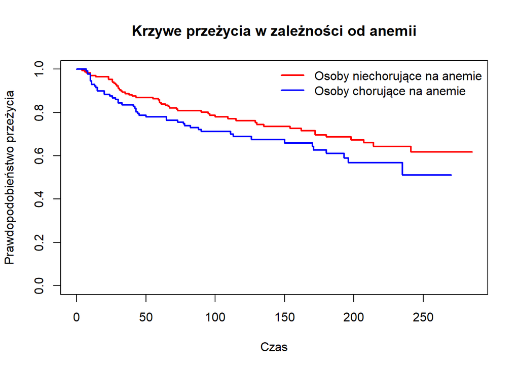

```r
summary(data$anaemia)

data$anaemia <- as.factor(data$anaemia)

surv_anaemia = survfit(Surv(data$time, data$DEATH_EVENT) ~ data$anaemia, data=data)
summary(surv_anaemia)

plot(surv_anaemia, col = c("red1", "blue"),main = "Krzywe przeżycia w zależności od anemii", xlab = "Czas", ylab = "Prawdopodobieństwo przeżycia", lwd = 2)
legend("topright", legend = c("Osoby niechorujące na anemie", "Osoby chorujące na anemie"),
       lty = 1, col = c("red1", "blue"), bty = "n", lwd = 2)
```

```r
a <- ten(surv_anaemia)
comp(a, p = c(0,1,1,0.5,0.5), q = c(1,0,1,0.5,2))
b <- attr(a, "tft")
print(cbind(b$tft$W, b$tft$pNorm))
```

## 6.7 Krzywe przeżycia w zależności od palenia papierosów

**Początkowe prawdopodobieństwo przeżycia:**

Na początku badania (czas = 0) prawdopodobieństwo przeżycia wynosi 1.0 (100%) dla obu grup.

**Przebieg krzywych w czasie:**

Obie grupy doświadczają systematycznego spadku przeżycia w miarę upływu czasu. Krzywe przeżycia osób palących i niepalących są do siebie bardzo zbliżone, co sugeruje, że palenie papierosów nie ma znaczącego wpływu na przeżycie w badanej populacji.

**Porównanie między grupami:**

W początkowej fazie badania (pierwsze 100 dni) krzywe są niemal identyczne. Po około 150 dniach różnice zaczynają się lekko zaznaczać, ale pozostają minimalne.

**Końcowa stabilizacja:**

Obie grupy osiągają podobny poziom stabilizacji przeżycia pod koniec badania (około 250 dni).

**Podsumowanie:**

Palenie papierosów wydaje się nie wpływać znacząco na przeżycie w tej badanej populacji. Różnice między osobami palącymi a niepalącymi są minimalne, co sugeruje, że inne czynniki (np. wiek, obecność cukrzycy, anemia) mogą mieć większe znaczenie w kontekście przeżycia.

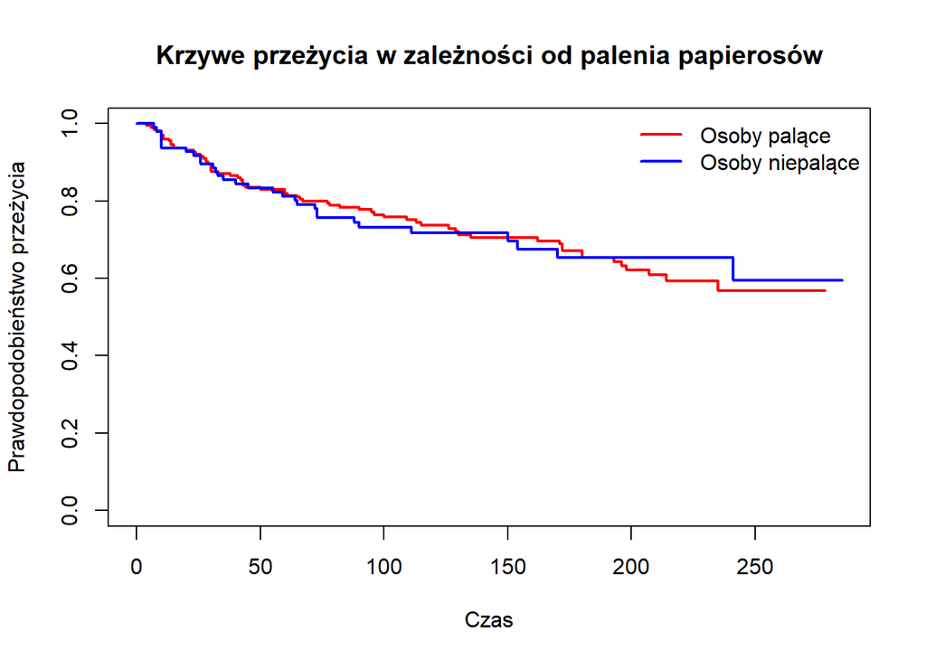

```r
summary(data$smoking)

data$smoking <- as.factor(data$smoking)

surv_smoking = survfit(Surv(data$time, data$DEATH_EVENT) ~ data$smoking, data=data)
summary(surv_smoking)

plot(surv_smoking, col = c("red1", "blue"),main = "Krzywe przeżycia w zależności od palenia papierosów", xlab = "Czas", ylab = "Prawdopodobieństwo przeżycia", lwd = 2)
legend("topright", legend = c("Osoby palące", "Osoby niepalące"),
       lty = 1, col = c("red1", "blue"), bty = "n", lwd = 2)
```

```r
a <- ten(surv_smoking)
comp(a, p = c(0,1,1,0.5,0.5), q = c(1,0,1,0.5,2))
b <- attr(a, "tft")
print(cbind(b$tft$W, b$tft$pNorm))
```

## 6.8 Krzywe przeżycia w zależności od wieku

**Przedział wiekowy:**

40-50 lat: Obejmuje młodszych pacjentów, gdzie liczba obserwacji jest stosunkowo niewielka. 51-60 lat: Widoczna koncentracja danych, sugerująca większą liczbę pacjentów w tym przedziale. 61-70 lat: Największy pik liczby obserwacji, reprezentujący dominującą grupę wiekową. 71-80 lat: Wyraźny spadek liczby pacjentów, ale nadal zauważalna liczba obserwacji. 81+ lat: Starsi pacjenci, którzy stanowią niewielką część próby.

**Początkowe prawdopodobieństwo przeżycia:**

Wszystkie grupy wiekowe zaczynają z prawdopodobieństwem przeżycia wynoszącym 1.0 (100%).

**Spadek przeżycia w zależności od wieku:**

**Końcowe różnice między grupami:**

**Różnice w czasie:**

**Podsumowanie:**

Wiek jest silnym czynnikiem różnicującym przeżycie w badanej populacji. Pacjenci w wieku powyżej 70 lat (szczególnie 81+) są najbardziej narażeni na zgony, co sugeruje, że wiek jest jednym z kluczowych czynników ryzyka. Młodsze grupy wiekowe (40-50 i 51-60 lat) mają znacznie lepsze wyniki przeżycia.

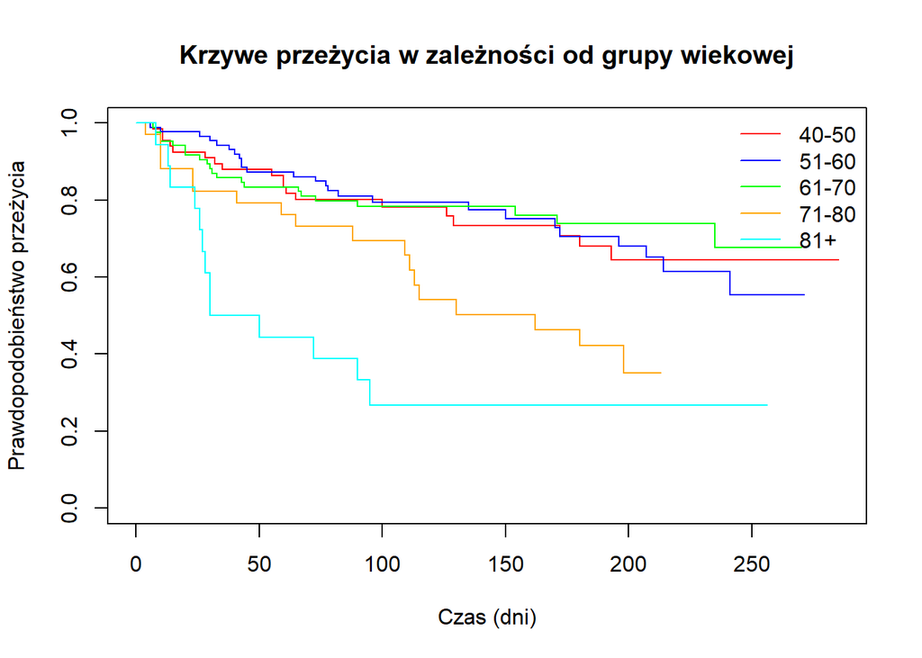

```r
summary(data$age)

# Upewniamy się, że zmienna age jest numeryczna
data$age <- as.numeric(data$age)

# Tworzymy nową zmienną age_group, która kategoryzuje wiek na trzy grupy
data$age_group <- cut(data$age, breaks = c(40, 50, 60, 70, 80, Inf), labels = c("40-50", "51-60", "61-70", "71-80", "81+"))

# Sprawdzamy rozkład nowej zmiennej age_group względem DEATH_EVENT
table(data$age_group, data$DEATH_EVENT)

# Tworzymy krzywą przeżycia dla grup wiekowych
surv_age = survfit(Surv(data$time, data$DEATH_EVENT) ~ data$age_group, data = data)

# Wykres krzywej przeżycia
plot(surv_age, col = c("red", "blue", "green", "orange", "cyan"), main = "Krzywe przeżycia w zależności od grupy wiekowej", xlab = "Czas (dni)", ylab = "Prawdopodobieństwo przeżycia")
legend("topright", c("40-50", "51-60", "61-70", "71-80", "81+"), lty = 1, col = c("red", "blue", "green", "orange", "cyan"), bty = "n")
```

```r
# Analiza statystyczna
a <- ten(surv_age)
comp(a, p = c(0, 1, 1, 0.5, 0.5), q = c(1, 0, 1, 0.5, 2))
b <- attr(a, "tft")
print(cbind(b$tft$W, b$tft$pNorm))
```

## 6.9 Histogram poziomu sodu w surowicy

**Najczęstsze wartości poziomu sodu:**

Największa liczba pacjentów ma poziom sodu w przedziale 135-145 mmol/L, co wskazuje, że większość wyników mieści się w zakresie normy.

**Skrajne wartości:**

Nieliczne przypadki obserwowane są na skrajach rozkładu: Poziom sodu poniżej 130 mmol/L jest rzadki, ale wskazuje na potencjalnie niebezpieczny stan hiponatremii. Poziom powyżej 145 mmol/L (hipernatremia) występuje sporadycznie.

**Rozkład danych:**

**Możliwe implikacje kliniczne:**

Pacjenci z poziomem sodu poza normą (poniżej 135 mmol/L lub powyżej 145 mmol/L) mogą być bardziej narażeni na poważne problemy zdrowotne, takie jak zaburzenia elektrolitowe, co może wymagać dalszej analizy.

**Podsumowanie:**

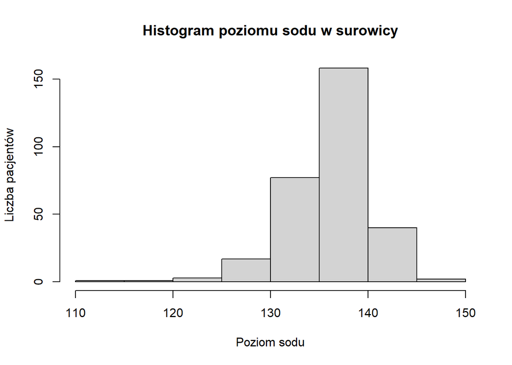

```r
data$serum_sodium <- as.numeric(data$serum_sodium)
summary(data$serum_sodium)
hist(data$serum_sodium, main = "Histogram poziomu sodu w surowicy", xlab = "Poziom sodu", ylab = "Liczba pacjentów")
```

## 6.10 Krzywe przeżycia w zależności od poziomu sodu w surowicy

Wykres przedstawia krzywe przeżycia pacjentów podzielonych na trzy grupy według poziomu sodu w surowicy:

120-130 mmol/L (linia czerwona). 131-140 mmol/L (linia niebieska). 141-150 mmol/L (linia zielona).

**Początkowe prawdopodobieństwo przeżycia:**

Wszystkie grupy rozpoczynają z prawdopodobieństwem przeżycia wynoszącym 1.0 (100%).

**Przebieg krzywych:**

- **Grupa 120-130 mmol/L (czerwona linia):** Wykazuje najszybszy spadek prawdopodobieństwa przeżycia, co wskazuje na najwyższe ryzyko zgonu wśród pacjentów z najniższym poziomem sodu.
- **Grupa 131-140 mmol/L (niebieska linia):** Charakteryzuje się umiarkowanym ryzykiem zgonu i lepszym przeżyciem niż grupa z najniższym poziomem sodu.
- **Grupa 141-150 mmol/L (zielona linia):** Ma najwyższe prawdopodobieństwo przeżycia przez cały okres obserwacji, co sugeruje, że wyższy poziom sodu jest związany z lepszymi wynikami.

**Różnice między grupami:**

**Końcowe prawdopodobieństwo przeżycia:**

Po 250 dniach przeżycie w grupie 141-150 mmol/L (zielona linia) jest najwyższe, a w grupie 120-130 mmol/L (czerwona linia) najniższe.

**Podsumowanie:**

Niski poziom sodu w surowicy (120-130 mmol/L) jest istotnym czynnikiem ryzyka i związany jest z najniższym przeżyciem. Wyższe poziomy sodu (131-140 mmol/L i 141-150 mmol/L) są związane z lepszymi wynikami przeżycia. Analiza wskazuje, że utrzymanie poziomu sodu w surowicy w wyższym zakresie może być korzystne dla pacjentów.

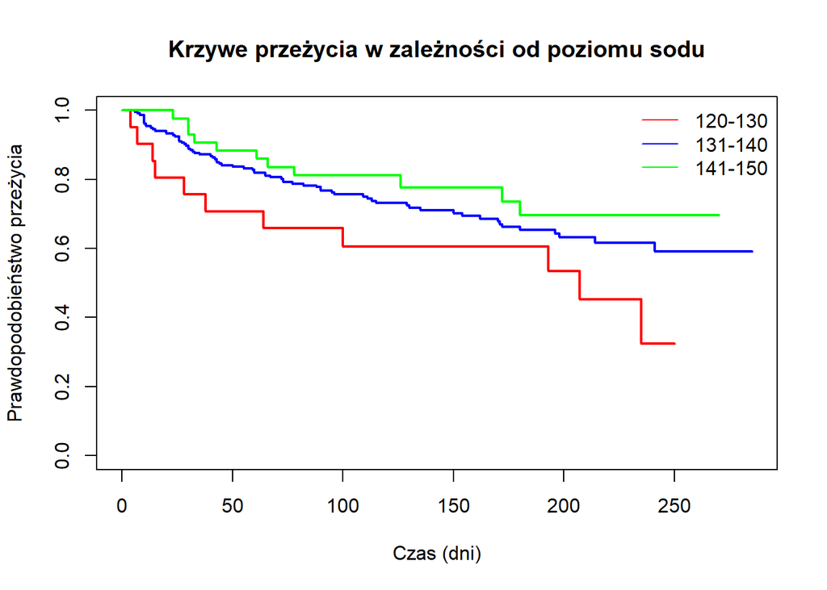

```r
# surv_serum_sodium=survfit(Surv(data$serum_sodium, data$DEATH_EVENT)~data$age_cat,data=data)
# a=ten(surv_serum_sodium)
# comp(a,p=c(0,1,1,0.5,0.5),q=c(1,0,1,0.5,2))
# b=attr(a,"tft")
# cbind(b$tft$W,b$tft$pNorm)

# Konwersja zmiennej poziomu sodu na kategorie z intuicyjnymi przedziałami
data$serum_sodium_cat <- cut(
  data$serum_sodium,
  breaks = c(120, 130, 140, 150),  # Przedziały bazujące na histogramie
  labels = c("120-130", "131-140", "141-150"),  # Intuicyjne etykiety
  include.lowest = TRUE
)

# Analiza przeżycia w zależności od poziomu sodu
serum_sodium_cat <- survfit(
  Surv(data$time, data$DEATH_EVENT) ~ data$serum_sodium_cat,
  data = data,
  conf.type = "none",
  type = "fleming-harrington"
)

# Wykres krzywych przeżycia
plot(
  serum_sodium_cat,
  col = c("red", "blue", "green"),
  main = "Krzywe przeżycia w zależności od poziomu sodu",
  xlab = "Czas (dni)",
  ylab = "Prawdopodobieństwo przeżycia",
  lwd = 2
)

# Legenda
legend(
  "topright",
  legend = c("120-130", "131-140", "141-150"),  # Aktualne przedziały
  lty = 1,
  col = c("red", "blue", "green"),
  bty = "n"
)
```

# 7 Model Coxa

Model proporcjonalnych hazardów (PH) Coxa to jedno z najczęściej stosowanych narzędzi w analizie przeżycia. Służy do badania wpływu zmiennych objaśniających na czas do wystąpienia określonego zdarzenia. Jest to model semiparametryczny – nie zakłada konkretnej postaci funkcji hazardu bazowego, lecz umożliwia ocenę wpływu zmiennych objaśniających na ryzyko zdarzenia.

Kluczową cechą modelu Coxa jest założenie proporcjonalności hazardów, co oznacza, że iloraz hazardów dla różnych jednostek pozostaje stały w czasie

Główne kroki w budowie modelu PH Coxa obejmą:

- oszacowanie parametrów modelu,
- weryfikację założenia proporcjonalności hazardów,
- wybór odpowiednich zmiennych i ich postaci,
- ocenę dopasowania modelu,
- analizę reszt w modelu.

```r
# Wyświetlenie kolumn danych
colnames(data)
```

```
##  [1] "age"                      "anaemia"
##  [3] "creatinine_phosphokinase" "diabetes"
##  [5] "ejection_fraction"        "high_blood_pressure"
##  [7] "platelets"                "serum_creatinine"
##  [9] "serum_sodium"             "sex"
## [11] "smoking"                  "time"
## [13] "DEATH_EVENT"              "age_group"
## [15] "serum_sodium_cat"
```

```r
# Model Coxa
cox_data_v1 <- coxph(
  Surv(time, DEATH_EVENT) ~
    age +
    anaemia +
    creatinine_phosphokinase +
    diabetes +
    ejection_fraction +
    high_blood_pressure +
    platelets +
    serum_creatinine +
    serum_sodium +
    sex +
    smoking,
  data = data
)

# Wyświetlenie wyników podsumowania modelu
summary(cox_data_v1)
```

```
## Call:
## coxph(formula = Surv(time, DEATH_EVENT) ~ age + anaemia + creatinine_phosphokinase +
##     diabetes + ejection_fraction + high_blood_pressure + platelets +
##     serum_creatinine + serum_sodium + sex + smoking, data = data)
##
##   n= 299, number of events= 96
##
##                                coef  exp(coef)   se(coef)      z Pr(>|z|)
## age                       4.641e-02  1.048e+00  9.324e-03  4.977 6.45e-07 ***
## anaemia1                  4.601e-01  1.584e+00  2.168e-01  2.122   0.0338 *
## creatinine_phosphokinase  2.207e-04  1.000e+00  9.919e-05  2.225   0.0260 *
## diabetes1                 1.399e-01  1.150e+00  2.231e-01  0.627   0.5307
## ejection_fraction        -4.894e-02  9.522e-01  1.048e-02 -4.672 2.98e-06 ***
## high_blood_pressure1      4.757e-01  1.609e+00  2.162e-01  2.201   0.0278 *
## platelets                -4.635e-07  1.000e+00  1.126e-06 -0.412   0.6806
## serum_creatinine          3.210e-01  1.379e+00  7.017e-02  4.575 4.76e-06 ***
## serum_sodium             -4.419e-02  9.568e-01  2.327e-02 -1.899   0.0575 .
## sex                      -2.375e-01  7.886e-01  2.516e-01 -0.944   0.3452
## smoking1                  1.289e-01  1.138e+00  2.512e-01  0.513   0.6078
## ---
## Signif. codes:  0 '***' 0.001 '**' 0.01 '*' 0.05 '.' 0.1 ' ' 1
##
##                          exp(coef) exp(-coef) lower .95 upper .95
## age                         1.0475     0.9547    1.0285     1.067
## anaemia1                    1.5843     0.6312    1.0358     2.423
## creatinine_phosphokinase    1.0002     0.9998    1.0000     1.000
## diabetes1                   1.1501     0.8695    0.7427     1.781
## ejection_fraction           0.9522     1.0502    0.9329     0.972
## high_blood_pressure1        1.6092     0.6214    1.0534     2.458
## platelets                   1.0000     1.0000    1.0000     1.000
## serum_creatinine            1.3786     0.7254    1.2014     1.582
## serum_sodium                0.9568     1.0452    0.9141     1.001
## sex                         0.7886     1.2681    0.4816     1.291
## smoking1                    1.1376     0.8790    0.6953     1.861
##
## Concordance= 0.741  (se = 0.027 )
## Likelihood ratio test= 81.95  on 11 df,   p=6e-13
## Wald test            = 87.27  on 11 df,   p=6e-14
## Score (logrank) test = 88.39  on 11 df,   p=3e-14
```

## 7.1 Interpretacja parametrów modelu Coxa:

**Zmienne statystycznie istotne (p < 0.05):**

**Wiek (age):**

Wraz ze wzrostem wieku o 1 rok, hazard (ryzyko zgonu pod warunkiem przeżycia do danego momentu) rośnie o 4,7% (HR = 1.047), zakładając, że pozostałe czynniki pozostają niezmienione (ceteris paribus).

**Anemia (anaemia):**

Pacjenci z anemią mają hazard o 58,4% wyższy (HR = 1.584) niż pacjenci bez anemii, przy założeniu niezmienności innych zmiennych.

**Kreatynina w surowicy (serum_creatinine):**

Wzrost poziomu kreatyniny w surowicy o 1 jednostkę powoduje wzrost hazardu o 37,8% (HR = 1.378), przy założeniu niezmienności pozostałych czynników.

**Ciśnienie krwi (high_blood_pressure):**

Pacjenci z nadciśnieniem tętniczym mają hazard o 60,9% wyższy (HR = 1.609) w porównaniu do pacjentów z prawidłowym ciśnieniem, przy niezmienności innych zmiennych.

**Frakcja wyrzutowa (ejection_fraction):**

Wzrost frakcji wyrzutowej o 1% wiąże się z spadkiem hazardu o 4,8% (HR = 0.952), zakładając, że pozostałe czynniki pozostają niezmienione.

**Fosfokinaza kreatynowa (creatinine_phosphokinase):**

Wzrost poziomu fosfokinazy kreatynowej o 1 jednostkę powoduje wzrost hazardu o 0,02% (HR = 1.0002), co jest istotne statystycznie, choć efekt jest bardzo niewielki.

**Zmienne marginalnie istotne (0.05 ≤ p < 0.1):**

**Poziom sodu w surowicy (serum_sodium):**

Wzrost poziomu sodu o 1 mmol/L powoduje spadek hazardu o 4,2% (HR = 0.958), jednak wynik jest marginalnie istotny (p = 0.057).

**Zmienne nieistotne statystycznie (p ≥ 0.1):**

**Cukrzyca (diabetes):**

Brak istotnego wpływu cukrzycy na hazard (p = 0.5307).

**Płeć (sex):**

Płeć nie ma istotnego wpływu na hazard (p = 0.3452).

**Palenie tytoniu (smoking):**

Różnice w hazardzie między osobami palącymi a niepalącymi nie są istotne statystycznie (p = 0.6078).

**Liczba płytek krwi (platelets):**

Liczba płytek krwi nie wpływa istotnie na hazard (p = 0.6806).

**Podsumowanie modelu:** Model Coxa wskazuje, że wiek, anemia, poziom kreatyniny w surowicy, ciśnienie krwi, frakcja wyrzutowa oraz poziom fosfokinazy kreatynowej mają istotny wpływ na przeżycie pacjentów. Wyższy poziom sodu w surowicy wydaje się obniżać ryzyko zgonu, jednak wynik jest marginalnie istotny. Pozostałe zmienne, takie jak cukrzyca, płeć, palenie tytoniu i liczba płytek, nie mają istotnego wpływu na ryzyko zgonu w tym modelu.

## 7.2 Estymacja modelu metoda krokowa ze wzgledu na kryterium akaike AIC (tu - metoda wsteczna)

W wyniku tej procedury otrzymano model z 7 zmiennymi objasniajacymi: wiek, anemia, kinazy kreatynowa,frakcja wyrzutowa serca,nadciśnienie tętnicze ,ilość kreatny w surowicy, ilosć sodu w surowicy.

```r
stepAIC(cox_data_v1,direction="backward")
```

```
## Start:  AIC=958.46
## Surv(time, DEATH_EVENT) ~ age + anaemia + creatinine_phosphokinase +
##     diabetes + ejection_fraction + high_blood_pressure + platelets +
##     serum_creatinine + serum_sodium + sex + smoking
##
##                            Df    AIC
## - platelets                 1 956.63
## - smoking                   1 956.72
## - diabetes                  1 956.85
## - sex                       1 957.34
## <none>                        958.46
## - serum_sodium              1 959.85
## - creatinine_phosphokinase  1 960.37
## - anaemia                   1 960.93
## - high_blood_pressure       1 961.15
## - serum_creatinine          1 971.27
## - ejection_fraction         1 980.75
## - age                       1 981.18
##
## Step:  AIC=956.63
## Surv(time, DEATH_EVENT) ~ age + anaemia + creatinine_phosphokinase +
##     diabetes + ejection_fraction + high_blood_pressure + serum_creatinine +
##     serum_sodium + sex + smoking
##
##                            Df    AIC
## - smoking                   1 954.84
## - diabetes                  1 954.98
## - sex                       1 955.40
## <none>                        956.63
## - serum_sodium              1 958.13
## - creatinine_phosphokinase  1 958.52
## - anaemia                   1 959.06
## - high_blood_pressure       1 959.22
## - serum_creatinine          1 969.71
## - ejection_fraction         1 978.88
## - age                       1 979.19
##
## Step:  AIC=954.84
## Surv(time, DEATH_EVENT) ~ age + anaemia + creatinine_phosphokinase +
##     diabetes + ejection_fraction + high_blood_pressure + serum_creatinine +
```

[output cut: 29 more lines]

```
##
## Step:  AIC=951.83
## Surv(time, DEATH_EVENT) ~ age + anaemia + creatinine_phosphokinase +
##     ejection_fraction + high_blood_pressure + serum_creatinine +
##     serum_sodium
##
##                            Df    AIC
## <none>                        951.83
## - serum_sodium              1 953.39
## - creatinine_phosphokinase  1 953.44
## - anaemia                   1 954.09
## - high_blood_pressure       1 955.04
## - serum_creatinine          1 964.37
## - age                       1 973.46
## - ejection_fraction         1 973.60
```

```
## Call:
## coxph(formula = Surv(time, DEATH_EVENT) ~ age + anaemia + creatinine_phosphokinase +
##     ejection_fraction + high_blood_pressure + serum_creatinine +
##     serum_sodium, data = data)
##
##                                coef  exp(coef)   se(coef)      z        p
## age                       4.357e-02  1.045e+00  8.831e-03  4.934 8.05e-07
## anaemia1                  4.460e-01  1.562e+00  2.150e-01  2.074   0.0380
## creatinine_phosphokinase  2.101e-04  1.000e+00  9.825e-05  2.138   0.0325
## ejection_fraction        -4.747e-02  9.536e-01  1.027e-02 -4.621 3.82e-06
## high_blood_pressure1      4.965e-01  1.643e+00  2.137e-01  2.324   0.0201
## serum_creatinine          3.139e-01  1.369e+00  6.895e-02  4.552 5.31e-06
## serum_sodium             -4.569e-02  9.553e-01  2.336e-02 -1.956   0.0505
##
## Likelihood ratio test=80.58  on 7 df, p=1.048e-14
## n= 299, number of events= 96
```

## 7.3 Otrzymany model z cox_data_v1 po użyciu AIC

```r
cox1_po_AIC <- coxph(formula = Surv(time, DEATH_EVENT) ~ age + anaemia + creatinine_phosphokinase +
    ejection_fraction + high_blood_pressure + serum_creatinine +
    serum_sodium, data = data)
summary(cox1_po_AIC)
```

```
## Call:
## coxph(formula = Surv(time, DEATH_EVENT) ~ age + anaemia + creatinine_phosphokinase +
##     ejection_fraction + high_blood_pressure + serum_creatinine +
##     serum_sodium, data = data)
##
##   n= 299, number of events= 96
##
##                                coef  exp(coef)   se(coef)      z Pr(>|z|)
## age                       4.357e-02  1.045e+00  8.831e-03  4.934 8.05e-07 ***
## anaemia1                  4.460e-01  1.562e+00  2.150e-01  2.074   0.0380 *
## creatinine_phosphokinase  2.101e-04  1.000e+00  9.825e-05  2.138   0.0325 *
## ejection_fraction        -4.747e-02  9.536e-01  1.027e-02 -4.621 3.82e-06 ***
## high_blood_pressure1      4.965e-01  1.643e+00  2.137e-01  2.324   0.0201 *
## serum_creatinine          3.139e-01  1.369e+00  6.895e-02  4.552 5.31e-06 ***
## serum_sodium             -4.569e-02  9.553e-01  2.336e-02 -1.956   0.0505 .
## ---
## Signif. codes:  0 '***' 0.001 '**' 0.01 '*' 0.05 '.' 0.1 ' ' 1
##
##                          exp(coef) exp(-coef) lower .95 upper .95
## age                         1.0445     0.9574    1.0266     1.063
## anaemia1                    1.5621     0.6402    1.0249     2.381
## creatinine_phosphokinase    1.0002     0.9998    1.0000     1.000
## ejection_fraction           0.9536     1.0486    0.9346     0.973
## high_blood_pressure1        1.6430     0.6086    1.0808     2.498
## serum_creatinine            1.3688     0.7306    1.1957     1.567
## serum_sodium                0.9553     1.0468    0.9126     1.000
##
## Concordance= 0.738  (se = 0.027 )
## Likelihood ratio test= 80.58  on 7 df,   p=1e-14
## Wald test            = 88.43  on 7 df,   p=3e-16
## Score (logrank) test = 87.66  on 7 df,   p=4e-16
```

## 7.4 WERYFIKACJA ZALOZENIA PROPORCJONALNOSCI

Kluczowym założeniem modelu Coxa jest proporcjonalność hazardów, czyli stałość ilorazu hazardów w czasie. Aby model prawidłowo odzwierciedlał wpływ zmiennych objaśniających na rozkład czasu trwania, to założenie musi być spełnione dla każdej zmiennej w modelu.

Jeżeli p > 0,05 to zostały spełnione zalożenia proporcjonalności dla zmiennej Ejection_fraction test nie wykazał spełnienia założenia, co oznacza konieczność usunięcia tej zmiennej z modelu.

```r
    km <- cox.zph(cox1_po_AIC, transform = 'km') #Kaplana-Meiera
    print(km)
```

```
##                             chisq df     p
## age                       0.05920  1 0.808
## anaemia                   0.00531  1 0.942
## creatinine_phosphokinase  0.98930  1 0.320
## ejection_fraction         4.76495  1 0.029
## high_blood_pressure       0.00943  1 0.923
## serum_creatinine          1.67518  1 0.196
## serum_sodium              0.09377  1 0.759
## GLOBAL                   10.52084  7 0.161
```

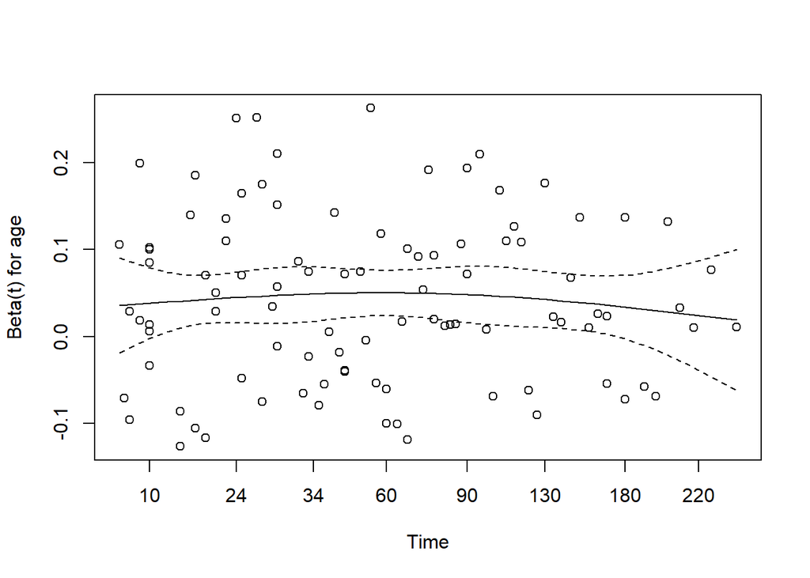

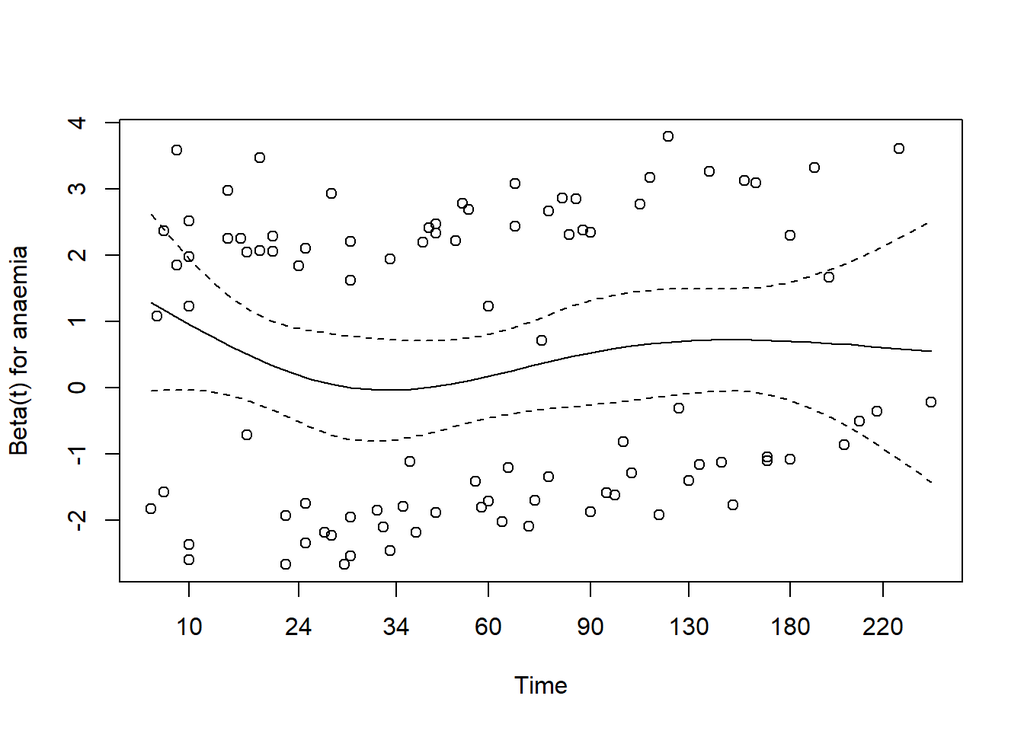

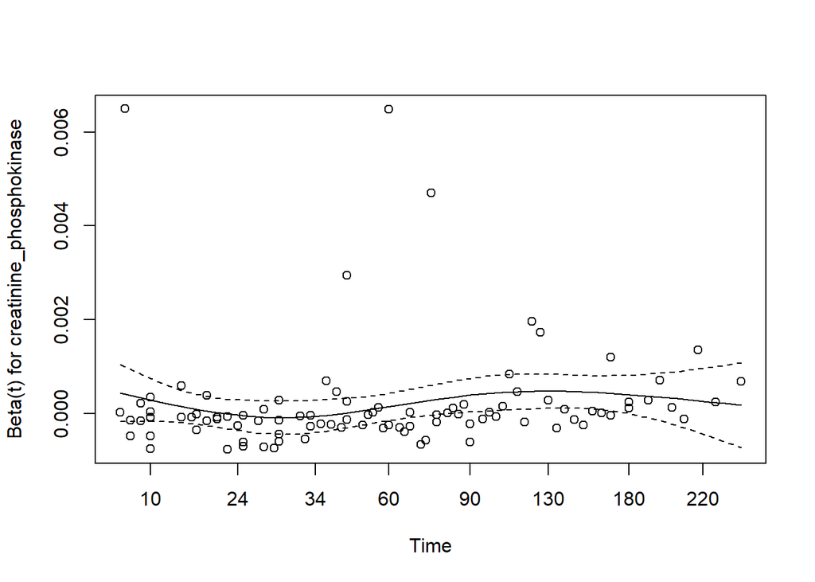

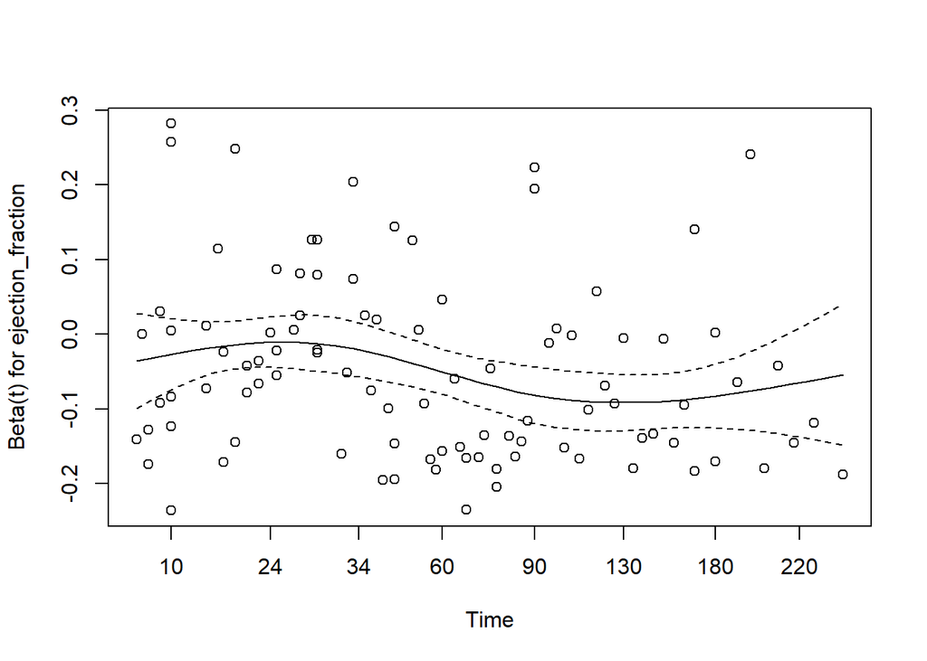

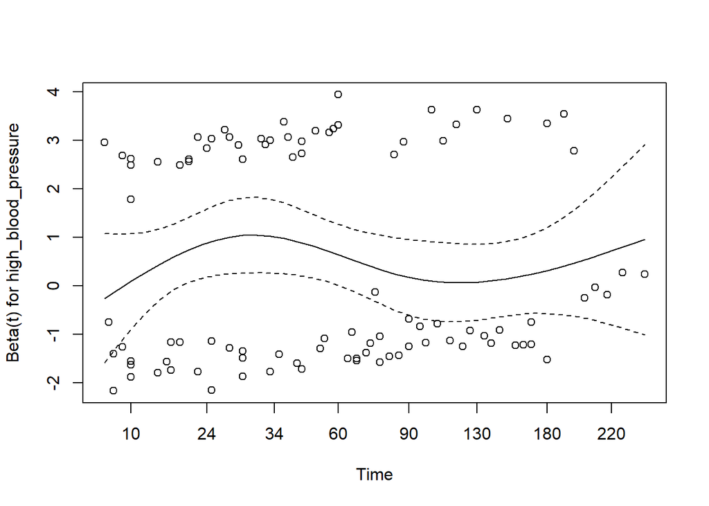

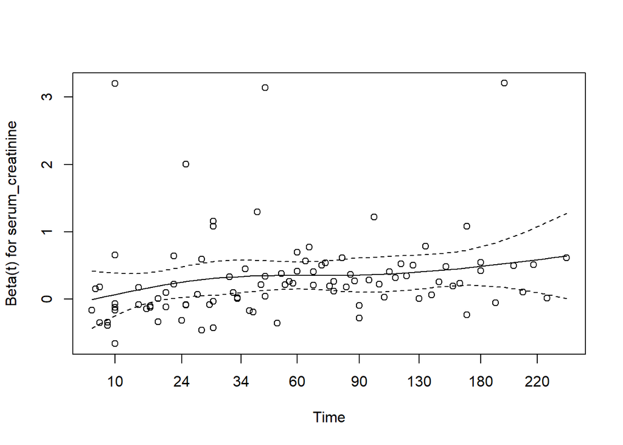

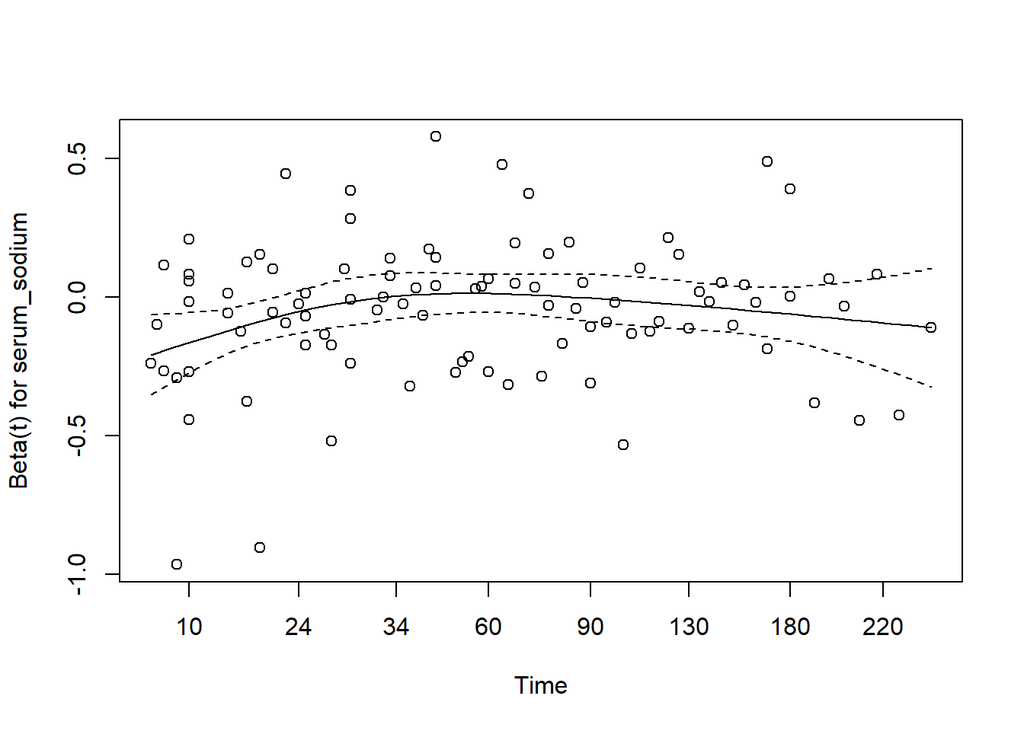

```r
    plot(km)
```